# Appendix

## Batter

#### Statistics

```r
print(dfSummary(batting_salary, graph.magnif = 0.75), method='render')
```

Data Frame Summary

batting_salary

**Dimensions**: 3028 x 33  
**Duplicates**: 0

| **No** | **Variable** | **Stats / Values** | **Freqs (% of Valid)** | **Graph** | **Valid** | **Missing** |
| --- | --- | --- | --- | --- | --- | --- |
| 1 | playerID [character] | 1. jeterde01 2. biggicr01 3. beltrad01 4. damonjo01 5. palmera01 6. pujolal01 7. rodrial01 8. rolliji01 9. hunteto01 10. ripkeca01 [ 786 others ] | 17 ( 0.6% ) 16 ( 0.5% ) 15 ( 0.5% ) 15 ( 0.5% ) 15 ( 0.5% ) 15 ( 0.5% ) 15 ( 0.5% ) 14 ( 0.5% ) 13 ( 0.4% ) 13 ( 0.4% ) 2880 ( 95.1% ) |  | 3028 (100%) | 0 (0%) |
| 2 | yearID [integer] | Mean (sd) : 2001.4 (9.1) min < med < max: 1985 < 2002 < 2016 IQR (CV) : 16 (0) | 31 distinct values |  | 3028 (100%) | 0 (0%) |
| 3 | teamID [factor] | 1. ALT 2. ANA 3. ARI 4. ATL 5. BAL 6. BFN 7. BFP 8. BL1 9. BL2 10. BL3 [ 139 others ] | 0 ( 0.0% ) 35 ( 1.2% ) 66 ( 2.2% ) 105 ( 3.5% ) 107 ( 3.5% ) 0 ( 0.0% ) 0 ( 0.0% ) 0 ( 0.0% ) 0 ( 0.0% ) 0 ( 0.0% ) 2715 ( 89.7% ) |  | 3028 (100%) | 0 (0%) |
| 4 | lgID [factor] | 1. AA 2. AL 3. FL 4. NA 5. NL 6. PL 7. UA | 0 ( 0.0% ) 1602 ( 52.9% ) 0 ( 0.0% ) 0 ( 0.0% ) 1426 ( 47.1% ) 0 ( 0.0% ) 0 ( 0.0% ) |  | 3028 (100%) | 0 (0%) |
| 5 | stint [integer] | Min : 1 Mean : 1 Max : 2 | 1 : 3022 ( 99.8% ) 2 : 6 ( 0.2% ) |  | 3028 (100%) | 0 (0%) |
| 6 | G [integer] | Mean (sd) : 150.9 (7.7) min < med < max: 121 < 152 < 163 IQR (CV) : 11 (0.1) | 40 distinct values |  | 3028 (100%) | 0 (0%) |
| 7 | AB [integer] | Mean (sd) : 570.1 (41.9) min < med < max: 502 < 567 < 716 IQR (CV) : 63 (0.1) | 193 distinct values |  | 3028 (100%) | 0 (0%) |
| 8 | R [integer] | Mean (sd) : 85.3 (18.1) min < med < max: 30 < 84 < 152 IQR (CV) : 25 (0.2) | 107 distinct values |  | 3028 (100%) | 0 (0%) |
| 9 | H [integer] | Mean (sd) : 161 (21.2) min < med < max: 106 < 160 < 262 IQR (CV) : 29 (0.1) | 124 distinct values |  | 3028 (100%) | 0 (0%) |
| 10 | X2B [integer] | Mean (sd) : 31.4 (7.7) min < med < max: 11 < 31 < 59 IQR (CV) : 10 (0.2) | 48 distinct values |  | 3028 (100%) | 0 (0%) |
| 11 | X3B [integer] | Mean (sd) : 3.6 (3) min < med < max: 0 < 3 < 23 IQR (CV) : 4 (0.8) | 23 distinct values |  | 3028 (100%) | 0 (0%) |
| 12 | HR [integer] | Mean (sd) : 20 (11.4) min < med < max: 0 < 19 < 70 IQR (CV) : 17 (0.6) | 63 distinct values |  | 3028 (100%) | 0 (0%) |
| 13 | RBI [integer] | Mean (sd) : 81 (24.5) min < med < max: 17 < 80 < 165 IQR (CV) : 37 (0.3) | 132 distinct values |  | 3028 (100%) | 0 (0%) |
| 14 | SB [integer] | Mean (sd) : 13.5 (14) min < med < max: 0 < 9 < 110 IQR (CV) : 17 (1) | 79 distinct values |  | 3028 (100%) | 0 (0%) |
| 15 | CS [integer] | Mean (sd) : 5.1 (4.3) min < med < max: 0 < 4 < 29 IQR (CV) : 5 (0.8) | 29 distinct values |  | 3028 (100%) | 0 (0%) |
| 16 | BB [integer] | Mean (sd) : 57.7 (23) min < med < max: 9 < 54 < 162 IQR (CV) : 31 (0.4) | 133 distinct values |  | 3028 (100%) | 0 (0%) |
| 17 | SO [integer] | Mean (sd) : 96.4 (33) min < med < max: 15 < 94 < 223 IQR (CV) : 45 (0.3) | 184 distinct values |  | 3028 (100%) | 0 (0%) |
| 18 | IBB [integer] | Mean (sd) : 5.6 (5.6) min < med < max: 0 < 4 < 44 IQR (CV) : 6 (1) | 40 distinct values |  | 3028 (100%) | 0 (0%) |
| 19 | HBP [integer] | Mean (sd) : 5.2 (4.3) min < med < max: 0 < 4 < 35 IQR (CV) : 5 (0.8) | 33 distinct values |  | 3028 (100%) | 0 (0%) |
| 20 | SH [integer] | Mean (sd) : 2.5 (3.8) min < med < max: 0 < 1 < 39 IQR (CV) : 4 (1.5) | 28 distinct values |  | 3028 (100%) | 0 (0%) |
| 21 | SF [integer] | Mean (sd) : 5.2 (2.6) min < med < max: 0 < 5 < 17 IQR (CV) : 4 (0.5) | 18 distinct values |  | 3028 (100%) | 0 (0%) |
| 22 | GIDP [integer] | Mean (sd) : 13 (5.4) min < med < max: 0 < 13 < 35 IQR (CV) : 8 (0.4) | 33 distinct values |  | 3028 (100%) | 0 (0%) |
| 23 | AVG [numeric] | Mean (sd) : 0.3 (0) min < med < max: 0.2 < 0.3 < 0.4 IQR (CV) : 0 (0.1) | 156 distinct values |  | 3028 (100%) | 0 (0%) |
| 24 | OBP [numeric] | Mean (sd) : 0.3 (0) min < med < max: 0.2 < 0.3 < 0.5 IQR (CV) : 0 (0.1) | 206 distinct values |  | 3028 (100%) | 0 (0%) |
| 25 | SLG [numeric] | Mean (sd) : 0.5 (0.1) min < med < max: 0.3 < 0.5 < 0.8 IQR (CV) : 0.1 (0.2) | 366 distinct values |  | 3028 (100%) | 0 (0%) |
| 26 | OPS [numeric] | Mean (sd) : 0.8 (0.1) min < med < max: 0.5 < 0.8 < 1.2 IQR (CV) : 0.1 (0.1) | 488 distinct values |  | 3028 (100%) | 0 (0%) |
| 27 | IsoP [numeric] | Mean (sd) : 0.2 (0.1) min < med < max: 0 < 0.2 < 0.5 IQR (CV) : 0.1 (0.4) | 301 distinct values |  | 3028 (100%) | 0 (0%) |
| 28 | IsoD [numeric] | Mean (sd) : 0.1 (0) min < med < max: 0 < 0.1 < 0.2 IQR (CV) : 0 (0.4) | 138 distinct values |  | 3028 (100%) | 0 (0%) |
| 29 | SecA [numeric] | Mean (sd) : 0.3 (0.1) min < med < max: 0.1 < 0.3 < 0.8 IQR (CV) : 0.1 (0.3) | 422 distinct values |  | 3028 (100%) | 0 (0%) |
| 30 | EqA [numeric] | Mean (sd) : 0.8 (0.1) min < med < max: 0.5 < 0.8 < 1.2 IQR (CV) : 0.1 (0.1) | 454 distinct values |  | 3028 (100%) | 0 (0%) |
| 31 | OPS_plus [numeric] | Mean (sd) : 2.8 (0.6) min < med < max: 0.7 < 2.8 < 4.8 IQR (CV) : 0.7 (0.2) | 1569 distinct values |  | 3028 (100%) | 0 (0%) |
| 32 | RC [numeric] | Mean (sd) : 82.8 (22.5) min < med < max: 27 < 80.6 < 183.5 IQR (CV) : 29.8 (0.3) | 2970 distinct values |  | 3028 (100%) | 0 (0%) |
| 33 | salary [integer] | Mean (sd) : 4083042 (4829380.2) min < med < max: 60000 < 2266666.5 < 3.3e+07 IQR (CV) : 5175000 (1.2) | 1128 distinct values |  | 3028 (100%) | 0 (0%) |

Generated by summarytools 0.9.6 ([R](https://www.r-project.org/) version 3.6.3)  
2020-05-28

#### LM

```r
summary(BatterModel)
```

```
##
## Call:
## lm(formula = salary ~ ., data = batting_salary)
##
## Residuals:
##       Min        1Q    Median        3Q       Max
## -10943416  -1050784         0   1030485  12276308
##
## Coefficients:
##                     Estimate Std. Error t value Pr(>|t|)
## (Intercept)       -1.857e+09  4.798e+07 -38.715  < 2e-16 ***
## playerIDabreujo02 -7.361e+06  1.887e+06  -3.901 9.89e-05 ***
## playerIDackledu01 -1.319e+07  2.130e+06  -6.193 7.06e-10 ***
## playerIDadamsma01 -1.377e+07  2.839e+06  -4.852 1.31e-06 ***
## playerIDalfoned01  9.013e+05  1.472e+06   0.612 0.540461
## playerIDalicelu01 -9.078e+05  2.841e+06  -0.320 0.749360
## playerIDalomaro01  7.257e+06  1.214e+06   5.976 2.67e-09 ***
## playerIDalonsyo01 -9.798e+06  2.854e+06  -3.433 0.000607 ***
## playerIDaloumo01   3.687e+06  1.456e+06   2.532 0.011402 *
## playerIDaltuvjo01 -1.235e+07  2.371e+06  -5.210 2.07e-07 ***
## playerIDalvarpe01 -1.180e+07  2.203e+06  -5.356 9.39e-08 ***
## playerIDanderbr01  5.859e+06  1.458e+06   4.020 6.03e-05 ***
## playerIDanderga01  6.764e+05  1.310e+06   0.516 0.605658
## playerIDanderma02 -3.459e+06  2.076e+06  -1.666 0.095816 .
## playerIDandruel01 -8.053e+06  1.457e+06  -5.526 3.67e-08 ***
## playerIDaokino01  -1.034e+07  2.211e+06  -4.678 3.08e-06 ***
## playerIDarenano01 -1.315e+07  2.198e+06  -5.980 2.60e-09 ***
## playerIDatkinga01 -5.858e+06  1.726e+06  -3.395 0.000698 ***
## playerIDaurilri01  1.105e+06  1.578e+06   0.700 0.483776
## playerIDausmubr01  2.424e+05  2.834e+06   0.086 0.931832
## playerIDavilemi01 -1.089e+07  2.869e+06  -3.795 0.000152 ***
## playerIDaybarer01 -1.014e+07  1.437e+06  -7.058 2.26e-12 ***
## playerIDbackmwa01  1.282e+07  2.875e+06   4.461 8.58e-06 ***
## playerIDbaergca01  5.816e+06  1.588e+06   3.664 0.000255 ***
## playerIDbagweje01  5.051e+06  1.367e+06   3.695 0.000225 ***
## playerIDbaineha01  1.044e+07  1.661e+06   6.284 3.98e-10 ***
## playerIDbalbost01  1.215e+07  2.218e+06   5.479 4.79e-08 ***
## playerIDbaldero01 -2.146e+06  2.178e+06  -0.986 0.324459
## playerIDbarfije01  1.184e+07  1.868e+06   6.339 2.80e-10 ***
## playerIDbarfijo02 -5.725e+06  2.842e+06  -2.014 0.044125 *
```

[output cut: 821 more lines]

```
## OBP               -4.128e+07  1.497e+08  -0.276 0.782735
## SLG               -5.154e+07  1.538e+08  -0.335 0.737557
## OPS                2.448e+07  1.237e+08   0.198 0.843167
## IsoP              -8.784e+06  1.287e+08  -0.068 0.945577
## IsoD              -9.837e+07  1.235e+08  -0.796 0.425977
## SecA               2.482e+07  2.550e+07   0.973 0.330484
## EqA                4.494e+07  3.082e+07   1.458 0.144892
## OPS_plus           7.040e+05  1.639e+05   4.294 1.83e-05 ***
## RC                -8.249e+03  4.527e+04  -0.182 0.855437
## ---
## Signif. codes:  0 '***' 0.001 '**' 0.01 '*' 0.05 '.' 0.1 ' ' 1
##
## Residual standard error: 2634000 on 2168 degrees of freedom
## Multiple R-squared:  0.7869, Adjusted R-squared:  0.7025
## F-statistic:  9.32 on 859 and 2168 DF,  p-value: < 2.2e-16
```

```r
round(summary(BatterModel)$coefficients, 4)
```

```
##                        Estimate   Std. Error  t value Pr(>|t|)
## (Intercept)       -1.857466e+09 4.797806e+07 -38.7149   0.0000
## playerIDabreujo02 -7.361328e+06 1.887233e+06  -3.9006   0.0001
## playerIDackledu01 -1.318988e+07 2.129957e+06  -6.1926   0.0000
## playerIDadamsma01 -1.377237e+07 2.838642e+06  -4.8517   0.0000
## playerIDalfoned01  9.013363e+05 1.472258e+06   0.6122   0.5405
## playerIDalicelu01 -9.078494e+05 2.841255e+06  -0.3195   0.7494
## playerIDalomaro01  7.257310e+06 1.214477e+06   5.9757   0.0000
## playerIDalonsyo01 -9.798266e+06 2.853821e+06  -3.4334   0.0006
## playerIDaloumo01   3.686846e+06 1.455930e+06   2.5323   0.0114
## playerIDaltuvjo01 -1.235085e+07 2.370549e+06  -5.2101   0.0000
## playerIDalvarpe01 -1.179914e+07 2.202804e+06  -5.3564   0.0000
## playerIDanderbr01  5.858687e+06 1.457551e+06   4.0195   0.0001
## playerIDanderga01  6.764132e+05 1.309975e+06   0.5164   0.6057
## playerIDanderma02 -3.459345e+06 2.076178e+06  -1.6662   0.0958
## playerIDandruel01 -8.053419e+06 1.457389e+06  -5.5259   0.0000
## playerIDaokino01  -1.034098e+07 2.210614e+06  -4.6779   0.0000
## playerIDarenano01 -1.314789e+07 2.198496e+06  -5.9804   0.0000
## playerIDatkinga01 -5.858323e+06 1.725512e+06  -3.3951   0.0007
## playerIDaurilri01  1.105467e+06 1.578422e+06   0.7004   0.4838
## playerIDausmubr01  2.424495e+05 2.834003e+06   0.0856   0.9318
## playerIDavilemi01 -1.088886e+07 2.869174e+06  -3.7951   0.0002
## playerIDaybarer01 -1.013999e+07 1.436619e+06  -7.0582   0.0000
## playerIDbackmwa01  1.282342e+07 2.874695e+06   4.4608   0.0000
## playerIDbaergca01  5.816240e+06 1.587543e+06   3.6637   0.0003
## playerIDbagweje01  5.051275e+06 1.367042e+06   3.6950   0.0002
## playerIDbaineha01  1.043885e+07 1.661232e+06   6.2838   0.0000
## playerIDbalbost01  1.215370e+07 2.218416e+06   5.4786   0.0000
## playerIDbaldero01 -2.146489e+06 2.177936e+06  -0.9856   0.3245
## playerIDbarfije01  1.184010e+07 1.867723e+06   6.3393   0.0000
## playerIDbarfijo02 -5.724985e+06 2.842485e+06  -2.0141   0.0441
## playerIDbarmecl01 -6.992702e+06 2.882102e+06  -2.4263   0.0153
## playerIDbarneda01 -1.208475e+07 2.178435e+06  -5.5474   0.0000
## playerIDbarrema02  1.055168e+07 1.815206e+06   5.8129   0.0000
## playerIDbartlja01 -7.714991e+06 2.117365e+06  -3.6437   0.0003
## playerIDbartoda02 -9.847676e+06 2.858730e+06  -3.4448   0.0006
## playerIDbasske01   9.941304e+06 1.766805e+06   5.6267   0.0000
## playerIDbatisto01 -1.390683e+06 1.854970e+06  -0.7497   0.4535
## playerIDbautida01 -1.622408e+05 2.856737e+06  -0.0568   0.9547
## playerIDbautijo02 -6.016133e+06 1.542605e+06  -3.9000   0.0001
```

[output cut: 806 more lines]

```
## IBB                6.231555e+04 1.671773e+04   3.7275   0.0002
## HBP                6.645593e+04 5.343910e+04   1.2436   0.2138
## SH                -5.865884e+04 2.511630e+04  -2.3355   0.0196
## SF                -7.417393e+04 4.399509e+04  -1.6860   0.0919
## GIDP               2.062899e+04 2.285768e+04   0.9025   0.3669
## AVG               -3.798917e+07 1.499393e+08  -0.2534   0.8000
## OBP               -4.128135e+07 1.496838e+08  -0.2758   0.7827
## SLG               -5.154105e+07 1.537926e+08  -0.3351   0.7376
## OPS                2.448318e+07 1.237347e+08   0.1979   0.8432
## IsoP              -8.783720e+06 1.286616e+08  -0.0683   0.9456
## IsoD              -9.836819e+07 1.235402e+08  -0.7962   0.4260
## SecA               2.481926e+07 2.549858e+07   0.9734   0.3305
## EqA                4.494281e+07 3.081782e+07   1.4583   0.1449
## OPS_plus           7.040239e+05 1.639364e+05   4.2945   0.0000
## RC                -8.248970e+03 4.527243e+04  -0.1822   0.8554
```

```r
confint(BatterModel)
```

```
##                           2.5 %        97.5 %
## (Intercept)       -1.951554e+09 -1.763378e+09
## playerIDabreujo02 -1.106230e+07 -3.660353e+06
## playerIDackledu01 -1.736685e+07 -9.012912e+06
## playerIDadamsma01 -1.933912e+07 -8.205628e+06
## playerIDalfoned01 -1.985847e+06  3.788520e+06
## playerIDalicelu01 -6.479717e+06  4.664018e+06
## playerIDalomaro01  4.875649e+06  9.638971e+06
## playerIDalonsyo01 -1.539478e+07 -4.201756e+06
## playerIDaloumo01   8.316815e+05  6.542010e+06
## playerIDaltuvjo01 -1.699964e+07 -7.702062e+06
## playerIDalvarpe01 -1.611897e+07 -7.479314e+06
## playerIDanderbr01  3.000344e+06  8.717030e+06
## playerIDanderga01 -1.892524e+06  3.245350e+06
## playerIDanderma02 -7.530852e+06  6.121622e+05
## playerIDandruel01 -1.091144e+07 -5.195393e+06
## playerIDaokino01  -1.467612e+07 -6.005831e+06
## playerIDarenano01 -1.745927e+07 -8.836511e+06
## playerIDatkinga01 -9.242154e+06 -2.474491e+06
## playerIDaurilri01 -1.989910e+06  4.200845e+06
## playerIDausmubr01 -5.315197e+06  5.800096e+06
## playerIDavilemi01 -1.651548e+07 -5.262243e+06
## playerIDaybarer01 -1.295728e+07 -7.322693e+06
## playerIDbackmwa01  7.185973e+06  1.846087e+07
## playerIDbaergca01  2.702975e+06  8.929504e+06
## playerIDbagweje01  2.370426e+06  7.732123e+06
## playerIDbaineha01  7.181079e+06  1.369662e+07
## playerIDbalbost01  7.803259e+06  1.650415e+07
## playerIDbaldero01 -6.417549e+06  2.124572e+06
## playerIDbarfije01  8.177391e+06  1.550282e+07
## playerIDbarfijo02 -1.129927e+07 -1.507052e+05
## playerIDbarmecl01 -1.264467e+07 -1.340731e+06
## playerIDbarneda01 -1.635679e+07 -7.812711e+06
## playerIDbarrema02  6.991949e+06  1.411140e+07
## playerIDbartlja01 -1.186727e+07 -3.562714e+06
## playerIDbartoda02 -1.545381e+07 -4.241538e+06
## playerIDbasske01   6.476495e+06  1.340611e+07
## playerIDbatisto01 -5.028387e+06  2.247022e+06
## playerIDbautida01 -5.764470e+06  5.439989e+06
## playerIDbautijo02 -9.041273e+06 -2.990994e+06
```

[output cut: 806 more lines]

```
## IBB                2.953110e+04  9.510000e+04
## HBP               -3.834130e+04  1.712532e+05
## SH                -1.079134e+05 -9.404307e+03
## SF                -1.604509e+05  1.210304e+04
## GIDP              -2.419627e+04  6.545424e+04
## AVG               -3.320289e+08  2.560505e+08
## OBP               -3.348200e+08  2.522573e+08
## SLG               -3.531373e+08  2.500552e+08
## OPS               -2.181678e+08  2.671341e+08
## IsoP              -2.610967e+08  2.435292e+08
## IsoD              -3.406379e+08  1.439015e+08
## SecA              -2.518494e+07  7.482347e+07
## EqA               -1.549275e+07  1.053784e+08
## OPS_plus           3.825350e+05  1.025513e+06
## RC                -9.703088e+04  8.053294e+04
```

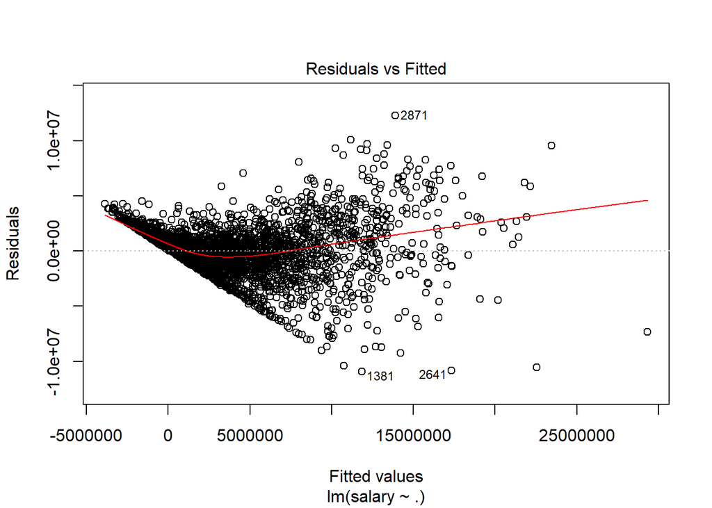

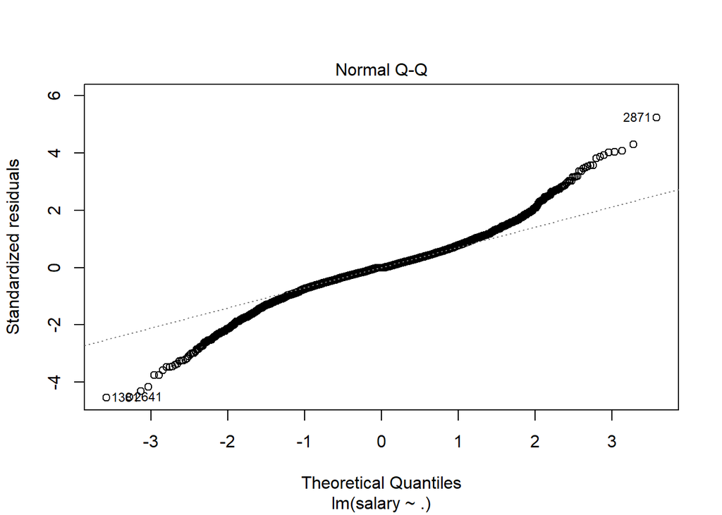

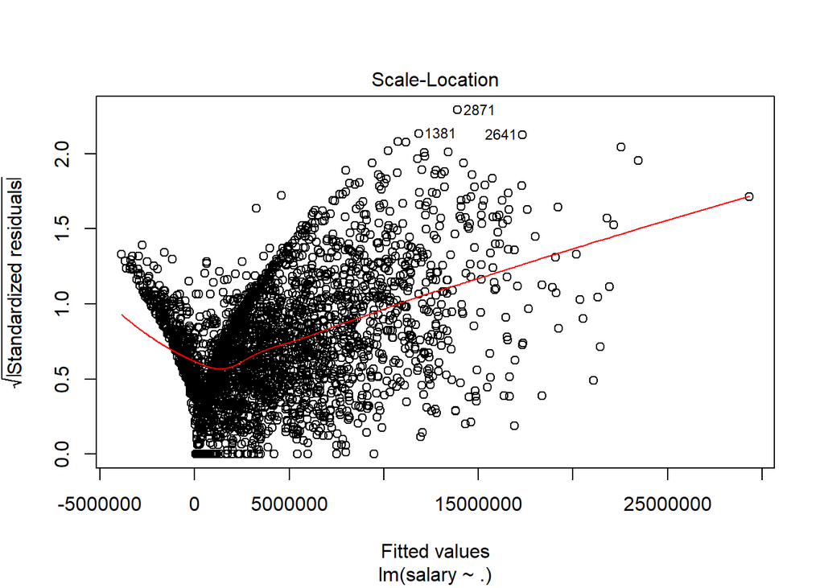

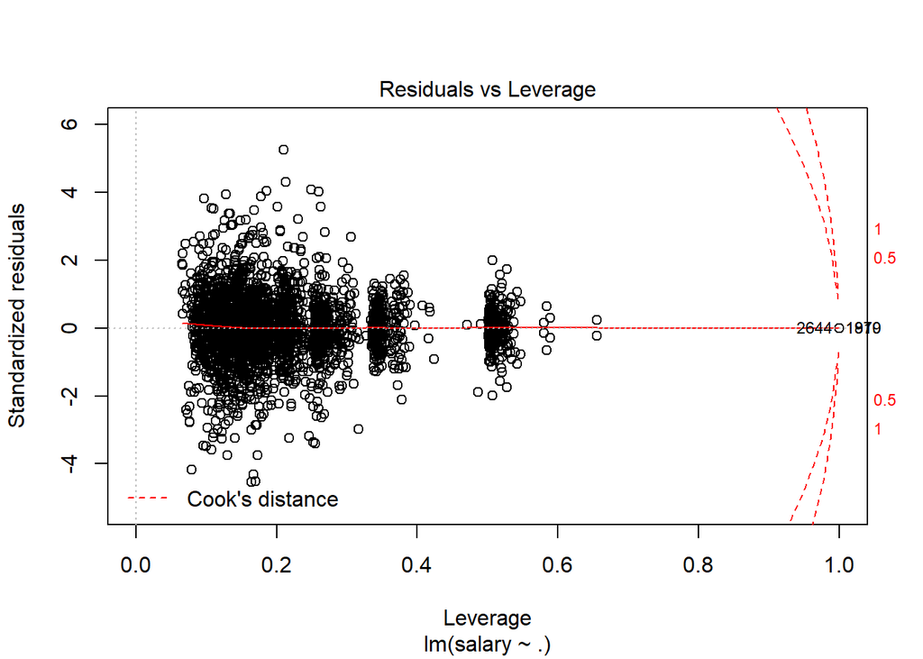

```r
plot(BatterModel)
```

當我們建立出一個線性回歸時，必須要確認其殘差(residual)是否符合下面三個假設：

常態性(Normality)

獨立性(Independence)

變異數同質性(Homogeneity of Variance)

故首先我們要先從回歸模型中找到殘差的值，可以使用names()函式，查看回歸模型內具有的資訊

```r
str(BatterModel)
```

```
## List of 13
##  $ coefficients : Named num [1:860] -1.86e+09 -7.36e+06 -1.32e+07 -1.38e+07 9.01e+05 ...
##   ..- attr(*, "names")= chr [1:860] "(Intercept)" "playerIDabreujo02" "playerIDackledu01" "playerIDadamsma01" ...
##  $ residuals    : Named num [1:3028] -1364523 625333 1387519 1723825 2383245 ...
##   ..- attr(*, "names")= chr [1:3028] "1" "2" "3" "4" ...
##  $ effects      : Named num [1:3028] -2.25e+08 8.71e+06 -3.08e+06 -3.56e+06 -2.04e+06 ...
##   ..- attr(*, "names")= chr [1:3028] "(Intercept)" "playerIDabreujo02" "playerIDackledu01" "playerIDadamsma01" ...
##  $ rank         : int 860
##  $ fitted.values: Named num [1:3028] 1764523 2308000 3595481 4609508 6716755 ...
##   ..- attr(*, "names")= chr [1:3028] "1" "2" "3" "4" ...
##  $ assign       : int [1:860] 0 1 1 1 1 1 1 1 1 1 ...
##  $ qr           :List of 5
##   ..$ qr   : num [1:3028, 1:860] -55.0273 0.0182 0.0182 0.0182 0.0182 ...
##   .. ..- attr(*, "dimnames")=List of 2
##   .. .. ..$ : chr [1:3028] "1" "2" "3" "4" ...
##   .. .. ..$ : chr [1:860] "(Intercept)" "playerIDabreujo02" "playerIDackledu01" "playerIDadamsma01" ...
##   .. ..- attr(*, "assign")= int [1:860] 0 1 1 1 1 1 1 1 1 1 ...
##   .. ..- attr(*, "contrasts")=List of 3
##   .. .. ..$ playerID: chr "contr.treatment"
##   .. .. ..$ teamID  : chr "contr.treatment"
##   .. .. ..$ lgID    : chr "contr.treatment"
##   ..$ qraux: num [1:860] 1.02 1 1 1 1 ...
##   ..$ pivot: int [1:860] 1 2 3 4 5 6 7 8 9 10 ...
##   ..$ tol  : num 1e-07
##   ..$ rank : int 860
##   ..- attr(*, "class")= chr "qr"
##  $ df.residual  : int 2168
##  $ contrasts    :List of 3
##   ..$ playerID: chr "contr.treatment"
##   ..$ teamID  : chr "contr.treatment"
##   ..$ lgID    : chr "contr.treatment"
##  $ xlevels      :List of 3
##   ..$ playerID: chr [1:796] "abreubo01" "abreujo02" "ackledu01" "adamsma01" ...
##   ..$ teamID  : chr [1:35] "ANA" "ARI" "ATL" "BAL" ...
##   ..$ lgID    : chr [1:2] "AL" "NL"
##  $ call         : language lm(formula = salary ~ ., data = batting_salary)
##  $ terms        :Classes 'terms', 'formula'  language salary ~ playerID + yearID + teamID + lgID + stint + G + AB + R + H + X2B +      X3B + HR + RBI + SB + CS + BB + | __truncated__ ...
##   .. ..- attr(*, "variables")= language list(salary, playerID, yearID, teamID, lgID, stint, G, AB, R, H, X2B, X3B,      HR, RBI, SB, CS, BB, SO, IBB, HBP| __truncated__ ...
##   .. ..- attr(*, "factors")= int [1:33, 1:32] 0 1 0 0 0 0 0 0 0 0 ...
##   .. .. ..- attr(*, "dimnames")=List of 2
```

[output cut: 44 more lines]

```
##   ..- attr(*, "terms")=Classes 'terms', 'formula'  language salary ~ playerID + yearID + teamID + lgID + stint + G + AB + R + H + X2B +      X3B + HR + RBI + SB + CS + BB + | __truncated__ ...
##   .. .. ..- attr(*, "variables")= language list(salary, playerID, yearID, teamID, lgID, stint, G, AB, R, H, X2B, X3B,      HR, RBI, SB, CS, BB, SO, IBB, HBP| __truncated__ ...
##   .. .. ..- attr(*, "factors")= int [1:33, 1:32] 0 1 0 0 0 0 0 0 0 0 ...
##   .. .. .. ..- attr(*, "dimnames")=List of 2
##   .. .. .. .. ..$ : chr [1:33] "salary" "playerID" "yearID" "teamID" ...
##   .. .. .. .. ..$ : chr [1:32] "playerID" "yearID" "teamID" "lgID" ...
##   .. .. ..- attr(*, "term.labels")= chr [1:32] "playerID" "yearID" "teamID" "lgID" ...
##   .. .. ..- attr(*, "order")= int [1:32] 1 1 1 1 1 1 1 1 1 1 ...
##   .. .. ..- attr(*, "intercept")= int 1
##   .. .. ..- attr(*, "response")= int 1
##   .. .. ..- attr(*, ".Environment")=<environment: R_GlobalEnv>
##   .. .. ..- attr(*, "predvars")= language list(salary, playerID, yearID, teamID, lgID, stint, G, AB, R, H, X2B, X3B,      HR, RBI, SB, CS, BB, SO, IBB, HBP| __truncated__ ...
##   .. .. ..- attr(*, "dataClasses")= Named chr [1:33] "numeric" "character" "numeric" "factor" ...
##   .. .. .. ..- attr(*, "names")= chr [1:33] "salary" "playerID" "yearID" "teamID" ...
##  - attr(*, "class")= chr "lm"
```

```r
names(BatterModel)
```

```
##  [1] "coefficients"  "residuals"     "effects"       "rank"
##  [5] "fitted.values" "assign"        "qr"            "df.residual"
##  [9] "contrasts"     "xlevels"       "call"          "terms"
## [13] "model"
```

其中，residuals就是指殘差的值(coefficients代表係數)，因此我們可以取出來後進行上面三個假設的檢定： 常態性假設 shapiro.test()函式可以用來檢驗殘差的常態性：

```r
shapiro.test(BatterModel$residual)
```

```
##
##  Shapiro-Wilk normality test
##
## data:  BatterModel$residual
## W = 0.94702, p-value < 2.2e-16
```

虛無假設H0:殘差服從常態分配，因為p-value < 0.05，代表拒絕H0。

獨立性假設 要檢驗殘差的獨立性，需要使用套件car中的durbinWatsonTest()函式：

```r
# 因為這個函式會自動去抓模型中的殘差，故這裡放的是模型，而不是殘差的值
durbinWatsonTest(BatterModel)
```

```
##  lag Autocorrelation D-W Statistic p-value
##    1       0.3643574      1.271072       0
##  Alternative hypothesis: rho != 0
```

虛無假設H0:殘差間相互獨立，因為p-value < 0.05，代表拒絕H0。

變異數同質性假設 要檢驗殘差的變異數同質性，需要使用套件car中的ncvTest()函式：

```r
# 因為這個函式會自動去抓模型中的殘差，故這裡放的是模型，而不是殘差的值
ncvTest(BatterModel)
```

```
## Non-constant Variance Score Test
## Variance formula: ~ fitted.values
## Chisquare = 1613.352, Df = 1, p = < 2.22e-16
```

虛無假設H0:殘差變異數具有同質性，因為p-value < 0.05，代表拒絕H0。

#### pcr

```
## Data:    X dimension: 3028 27
##  Y dimension: 3028 1
## Fit method: svdpc
## Number of components considered: 27
##
## VALIDATION: RMSEP
## Cross-validated using 10 random segments.
##        (Intercept)  1 comps  2 comps  3 comps  4 comps  5 comps  6 comps
## CV         4830178  4634862  4583814  4569529  4570286  4555703  4543025
## adjCV      4830178  4634764  4583597  4569246  4569958  4555278  4542543
##        7 comps  8 comps  9 comps  10 comps  11 comps  12 comps  13 comps
## CV     4525288  4514439  4509967   4511028   4510440   4492874   4490422
## adjCV  4524798  4513831  4509266   4510301   4509709   4492031   4489548
##        14 comps  15 comps  16 comps  17 comps  18 comps  19 comps  20 comps
## CV      4492136   4385309   4386148   4382126   4374523   4367928   4362526
## adjCV   4491498   4384175   4384882   4380799   4373152   4366465   4360872
##        21 comps  22 comps  23 comps  24 comps  25 comps  26 comps  27 comps
## CV      4360302   4336048   4333744   4331364   4331948   4332132   4332129
## adjCV   4358581   4334143   4331741   4329327   4329867   4330005   4329921
##
## TRAINING: % variance explained
##         1 comps  2 comps  3 comps  4 comps  5 comps  6 comps  7 comps  8 comps
## X        40.206    53.78    63.29    70.40    75.41    79.40    82.74    85.38
## salary    7.936    10.03    10.65    10.66    11.25    11.81    12.53    13.04
##         9 comps  10 comps  11 comps  12 comps  13 comps  14 comps  15 comps
## X         87.85     90.20     92.31     94.16     95.78     97.06     98.19
## salary    13.24     13.27     13.32     14.05     14.17     14.22     18.30
##         16 comps  17 comps  18 comps  19 comps  20 comps  21 comps  22 comps
## X          99.03     99.53     99.93     99.97     99.98     99.99    100.00
## salary     18.39     18.59     18.90     19.21     19.54     19.67     20.69
##         23 comps  24 comps  25 comps  26 comps  27 comps
## X         100.00    100.00    100.00       100    100.00
## salary     20.86     20.97     20.98        21     21.06
```

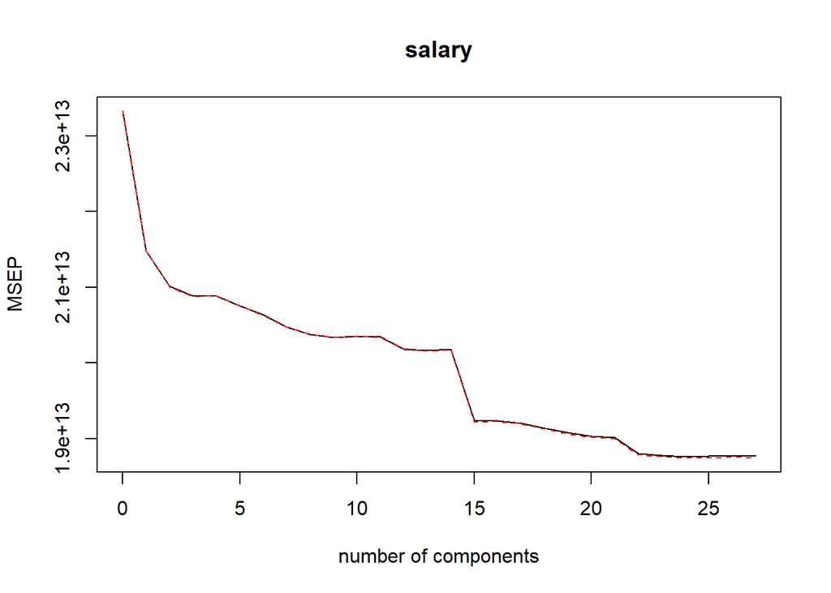

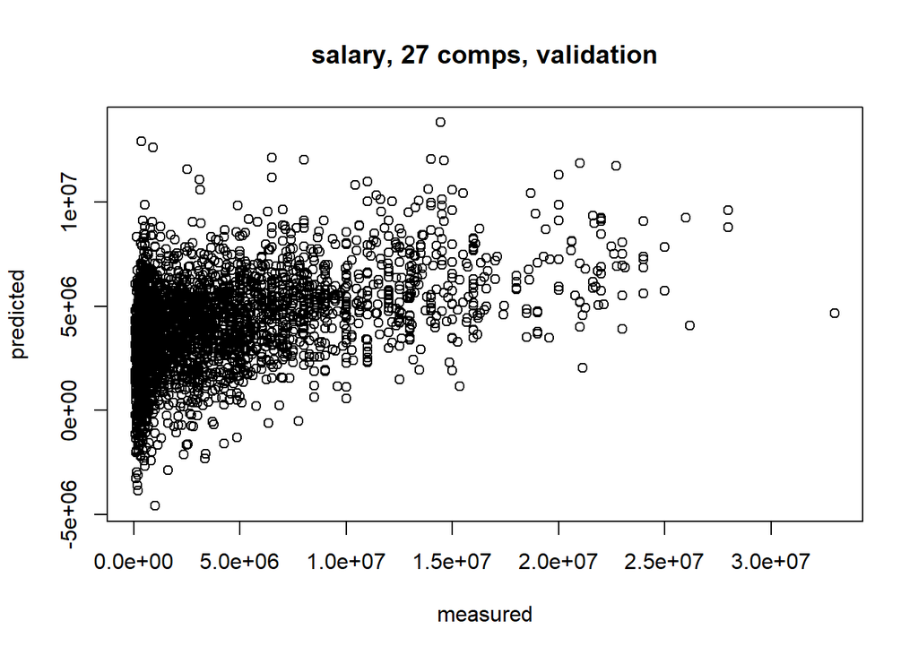

[output not shown]

```
## , , 1 comps
##
##                  salary
## (Intercept) -5418428.44
## G              37631.45
## AB             22396.96
## R              91853.00
## H              64332.64
## X2B            64839.66
## X3B           -17173.57
## HR            100793.06
## RBI           101672.99
## SB            -17014.07
## CS            -26221.43
## BB             85014.82
## SO             31937.41
## IBB            70566.88
## HBP            27613.29
## SH            -61135.92
## SF             32109.24
## GIDP           12882.14
## AVG            73282.79
## OBP           101405.40
## SLG           117718.51
## OPS           122127.31
## IsoP          106319.70
## IsoD           72834.44
## SecA          111088.55
## EqA           121130.26
## OPS_plus       97139.61
## RC            116715.18
##
## , , 2 comps
##
##                  salary
## (Intercept) -113608.293
## G            -11629.945
## AB           -90014.219
## R              5492.345
## H            -70370.529
```

[output cut: 40 more lines]

```
## IBB            88517.357
## HBP             8238.543
## SH           -167869.032
## SF             95481.259
## GIDP          142110.725
## AVG            18314.637
## OBP            23481.234
## SLG           151187.419
## OPS           117848.404
## IsoP          169466.371
## IsoD           15471.717
## SecA           90166.032
## EqA            91926.516
## OPS_plus       98481.773
## RC             56380.714
```

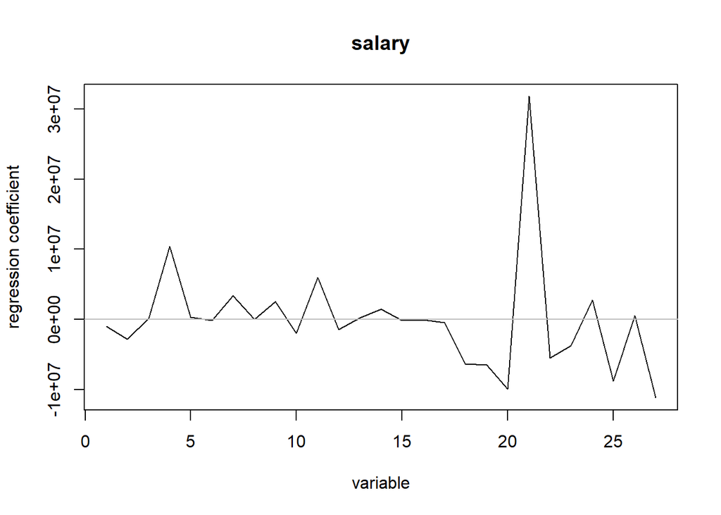

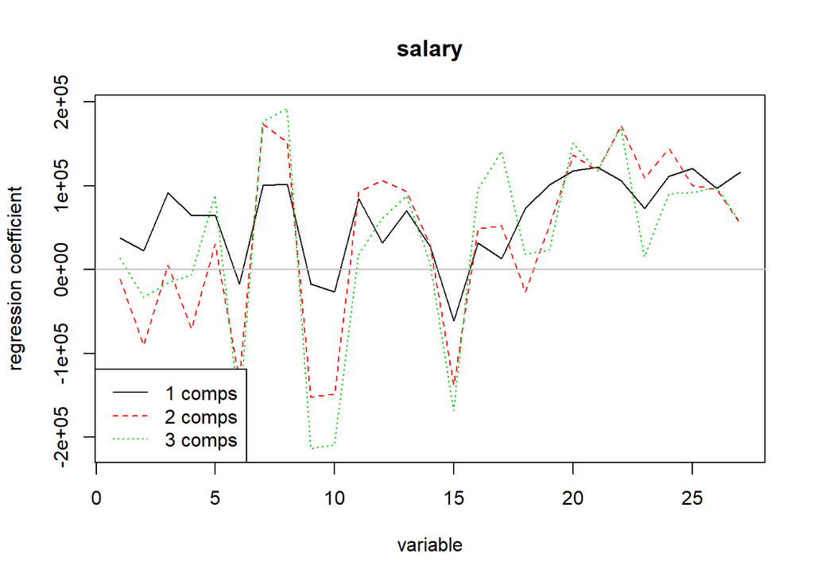

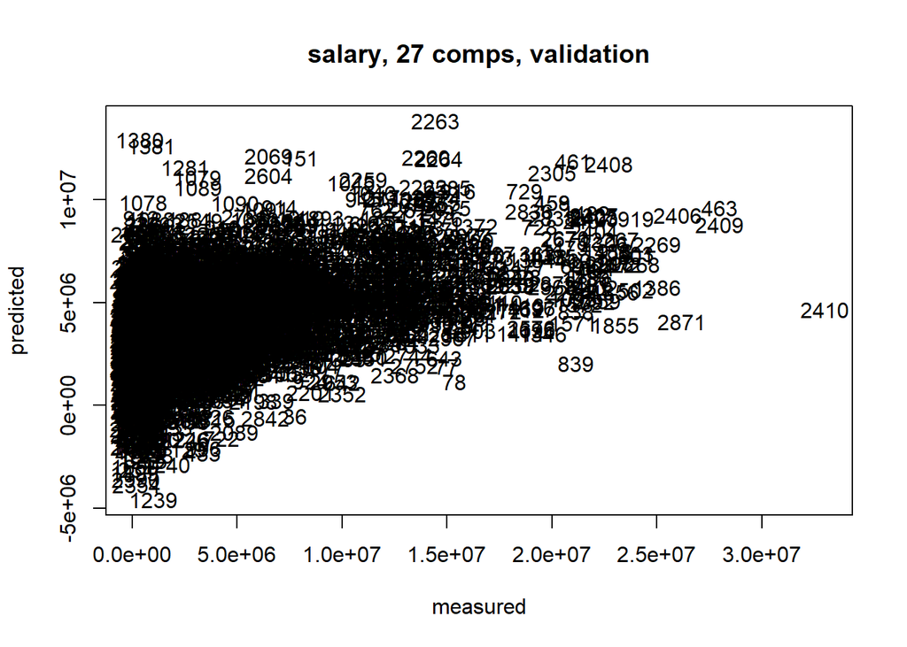

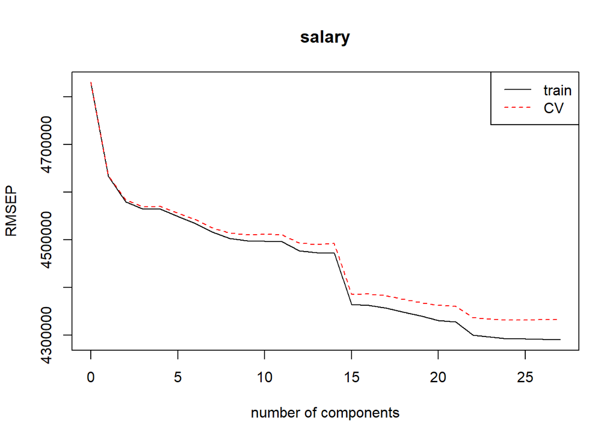

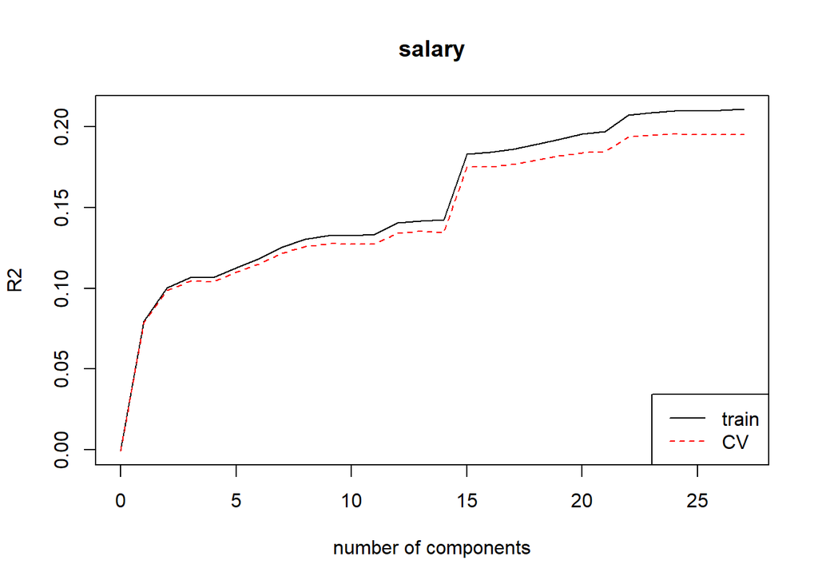

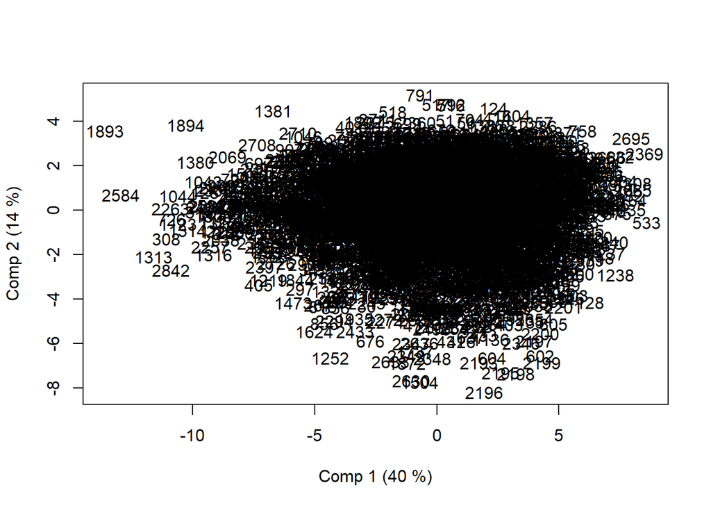

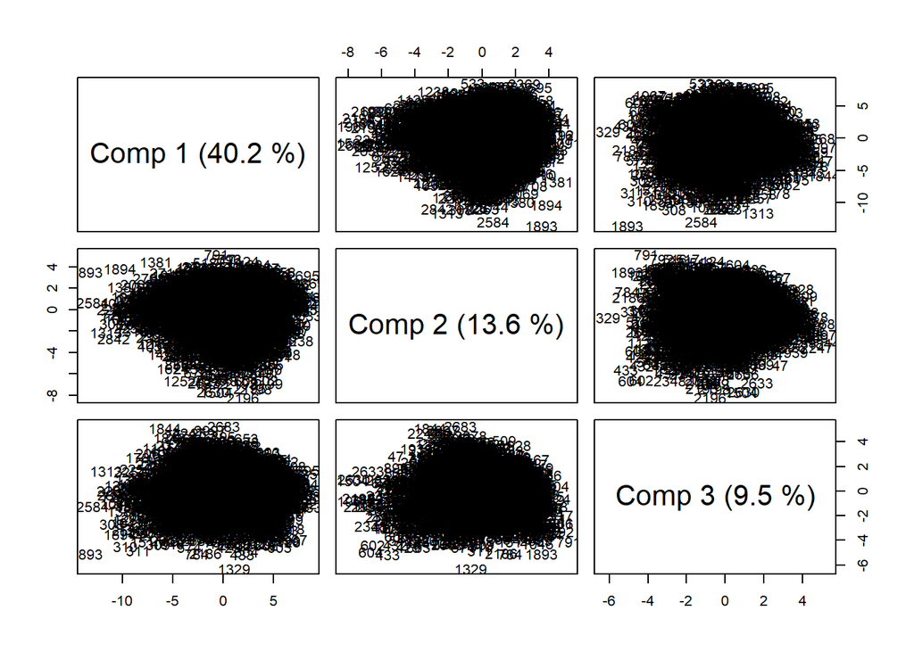

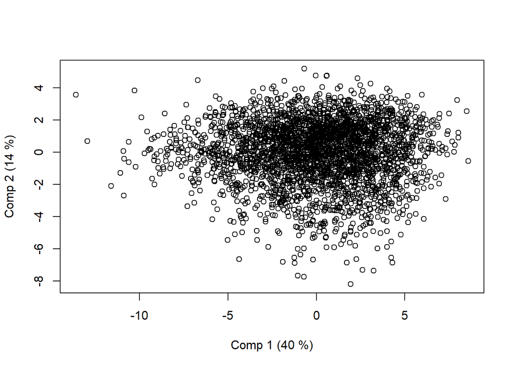

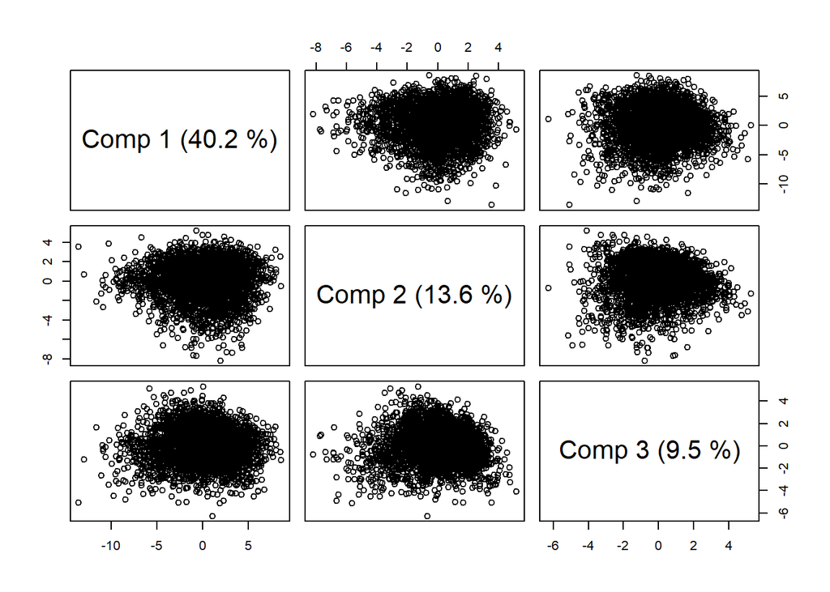

[figure not shown]

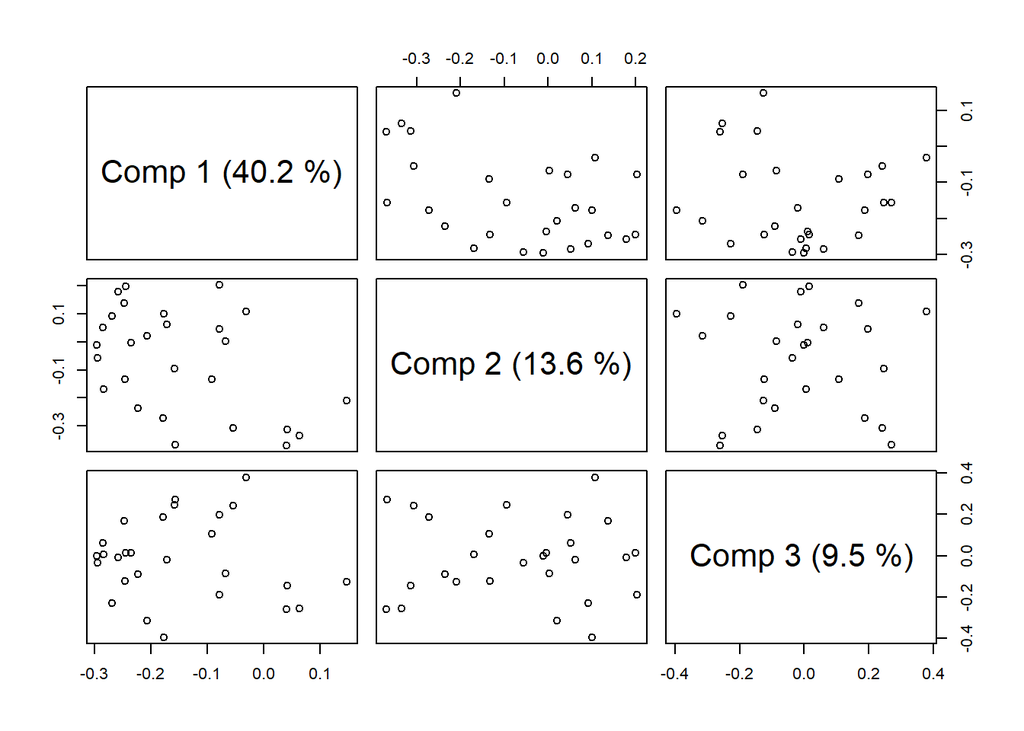

```
## Data:    X dimension: 2122 27
##  Y dimension: 2122 1
## Fit method: svdpc
## Number of components considered: 27
##
## VALIDATION: RMSEP
## Cross-validated using 10 random segments.
##        (Intercept)  1 comps  2 comps  3 comps  4 comps  5 comps  6 comps
## CV         4771556  4712370  4614475  4597445  4577312  4557298  4560046
## adjCV      4771556  4712186  4614117  4597043  4576787  4556703  4559136
##        7 comps  8 comps  9 comps  10 comps  11 comps  12 comps  13 comps
## CV     4564494  4559056  4559243   4445047   4433840   4433749   4416408
## adjCV  4563306  4557831  4557959   4435681   4431976   4431949   4414511
##        14 comps  15 comps  16 comps  17 comps  18 comps  19 comps  20 comps
## CV      4407501   4409126   4366084   4370610   4313678   4289762   4292308
## adjCV   4405372   4407037   4363862   4368193   4311336   4287104   4289487
##        21 comps  22 comps  23 comps  24 comps  25 comps  26 comps  27 comps
## CV      4271235   4271601   4272782   4273768   4275647   4277942   4279560
## adjCV   4268293   4268484   4269583   4270517   4272308   4274385   4275919
##
## TRAINING: % variance explained
##         1 comps  2 comps  3 comps  4 comps  5 comps  6 comps  7 comps  8 comps
## X         41.94   66.584    82.80    90.12   93.746   95.754   96.946   97.615
## salary     2.55    6.674     7.39     8.29    9.149    9.274    9.317    9.604
##         9 comps  10 comps  11 comps  12 comps  13 comps  14 comps  15 comps
## X         98.21     98.60     98.96     99.27     99.51     99.66     99.80
## salary     9.65     14.54     14.80     14.91     15.64     16.06     16.11
##         16 comps  17 comps  18 comps  19 comps  20 comps  21 comps  22 comps
## X          99.90     99.99    100.00    100.00    100.00    100.00    100.00
## salary     17.76     17.78     19.87     20.99     21.01     21.87     21.98
##         23 comps  24 comps  25 comps  26 comps  27 comps
## X         100.00       100       100    100.00    100.00
## salary     21.99        22        22     22.05     22.05
```

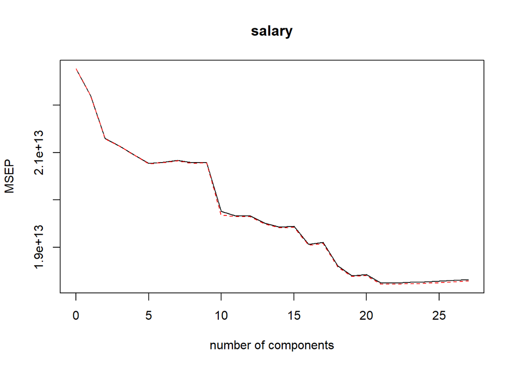

```
## Data:    X dimension: 2122 27
##  Y dimension: 2122 1
## Fit method: svdpc
## Number of components considered: 27
##
## VALIDATION: RMSEP
## Cross-validated using 10 random segments.
##        (Intercept)  1 comps  2 comps  3 comps  4 comps  5 comps  6 comps
## CV         4771556  4573356  4513787  4501834  4504521  4499425  4498788
## adjCV      4771556  4573080  4513350  4501147  4503680  4498276  4497473
##        7 comps  8 comps  9 comps  10 comps  11 comps  12 comps  13 comps
## CV     4479731  4468440  4466762   4467673   4464688   4448771   4445698
## adjCV  4478230  4466710  4464984   4465979   4462946   4446950   4443734
##        14 comps  15 comps  16 comps  17 comps  18 comps  19 comps  20 comps
## CV      4438946   4336622   4337920   4339065   4330821   4325064   4315605
## adjCV   4437389   4334430   4335687   4336690   4328305   4322410   4312903
##        21 comps  22 comps  23 comps  24 comps  25 comps  26 comps  27 comps
## CV      4316922   4277176   4275598   4276562   4278624   4279593   4281398
## adjCV   4313981   4274009   4272310   4273163   4275112   4276013   4277666
##
## TRAINING: % variance explained
##         1 comps  2 comps  3 comps  4 comps  5 comps  6 comps  7 comps  8 comps
## X        40.378    53.80    63.30    70.34    75.35    79.35    82.72    85.39
## salary    8.257    10.76    11.43    11.43    11.88    12.05    12.85    13.28
##         9 comps  10 comps  11 comps  12 comps  13 comps  14 comps  15 comps
## X         87.89     90.28     92.39     94.24     95.87     97.11     98.23
## salary    13.51     13.53     13.72     14.33     14.59     14.97     18.85
##         16 comps  17 comps  18 comps  19 comps  20 comps  21 comps  22 comps
## X          99.04     99.53     99.93     99.97     99.98     99.99     100.0
## salary     18.89     18.96     19.35     19.67     20.05     20.18      21.8
##         23 comps  24 comps  25 comps  26 comps  27 comps
## X         100.00       100       100    100.00    100.00
## salary     21.96        22        22     22.02     22.05
```

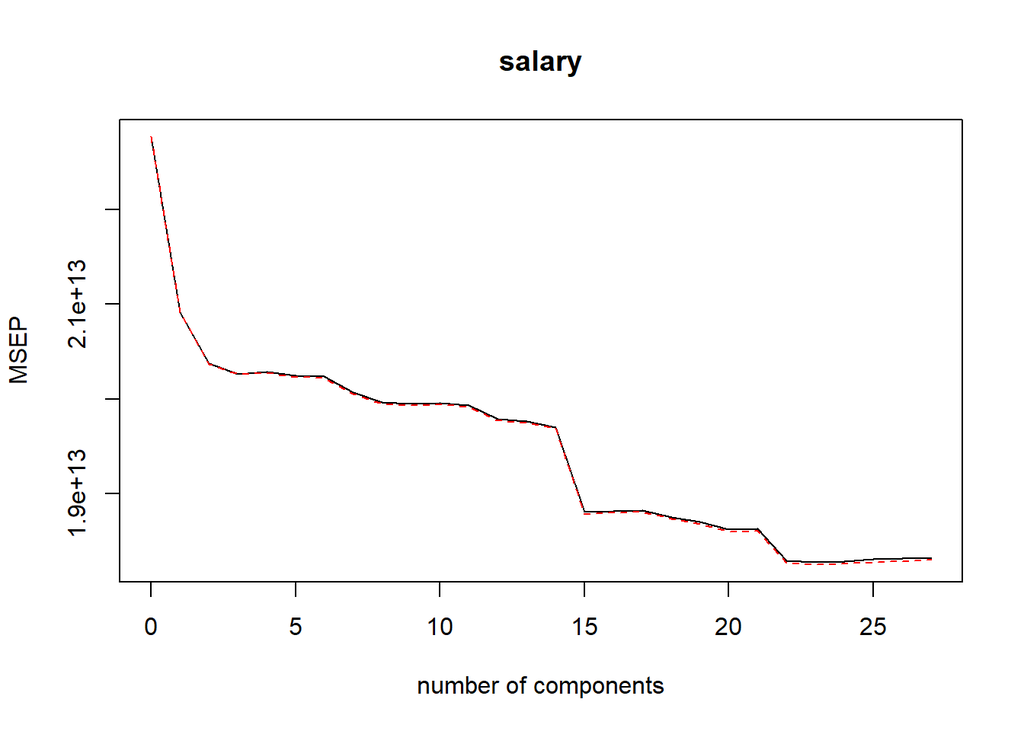

## Team

#### Statistics

```r
print(dfSummary(Teams1985_2016, graph.magnif = 0.75), method='render')
```

Data Frame Summary

Teams1985_2016

**Dimensions**: 918 x 38  
**Duplicates**: 0

| **No** | **Variable** | **Stats / Values** | **Freqs (% of Valid)** | **Graph** | **Valid** | **Missing** |
| --- | --- | --- | --- | --- | --- | --- |
| 1 | yearID [integer] | Mean (sd) : 2001 (9.1) min < med < max: 1985 < 2001 < 2016 IQR (CV) : 16 (0) | 32 distinct values |  | 918 (100%) | 0 (0%) |
| 2 | teamID [factor] | 1. ALT 2. ANA 3. ARI 4. ATL 5. BAL 6. BFN 7. BFP 8. BL1 9. BL2 10. BL3 [ 139 others ] | 0 ( 0.0% ) 8 ( 0.9% ) 19 ( 2.1% ) 32 ( 3.5% ) 32 ( 3.5% ) 0 ( 0.0% ) 0 ( 0.0% ) 0 ( 0.0% ) 0 ( 0.0% ) 0 ( 0.0% ) 827 ( 90.1% ) |  | 918 (100%) | 0 (0%) |
| 3 | lgID [factor] | 1. AA 2. AL 3. FL 4. NA 5. NL 6. PL 7. UA | 0 ( 0.0% ) 452 ( 49.2% ) 0 ( 0.0% ) 0 ( 0.0% ) 466 ( 50.8% ) 0 ( 0.0% ) 0 ( 0.0% ) |  | 918 (100%) | 0 (0%) |
| 4 | G [integer] | Mean (sd) : 159.9 (8.7) min < med < max: 112 < 162 < 164 IQR (CV) : 0 (0.1) | 13 distinct values |  | 918 (100%) | 0 (0%) |
| 5 | Ghome [integer] | Mean (sd) : 80 (4.4) min < med < max: 44 < 81 < 84 IQR (CV) : 0 (0.1) | 25 distinct values |  | 918 (100%) | 0 (0%) |
| 6 | W [integer] | Mean (sd) : 79.9 (11.8) min < med < max: 43 < 80 < 116 IQR (CV) : 17.8 (0.1) | 62 distinct values |  | 918 (100%) | 0 (0%) |
| 7 | L [integer] | Mean (sd) : 79.9 (11.8) min < med < max: 40 < 79 < 119 IQR (CV) : 16.8 (0.1) | 65 distinct values |  | 918 (100%) | 0 (0%) |
| 8 | R [integer] | Mean (sd) : 730 (89.9) min < med < max: 466 < 729 < 1009 IQR (CV) : 119 (0.1) | 337 distinct values |  | 918 (100%) | 0 (0%) |
| 9 | AB [integer] | Mean (sd) : 5469.4 (300.3) min < med < max: 3856 < 5524 < 5781 IQR (CV) : 113.8 (0.1) | 350 distinct values |  | 918 (100%) | 0 (0%) |
| 10 | H [integer] | Mean (sd) : 1430.2 (105.9) min < med < max: 963 < 1434 < 1684 IQR (CV) : 116 (0.1) | 343 distinct values |  | 918 (100%) | 0 (0%) |
| 11 | X2B [integer] | Mean (sd) : 275.3 (34.2) min < med < max: 159 < 276 < 376 IQR (CV) : 42 (0.1) | 162 distinct values |  | 918 (100%) | 0 (0%) |
| 12 | X3B [integer] | Mean (sd) : 31 (9.1) min < med < max: 6 < 30 < 61 IQR (CV) : 13 (0.3) | 51 distinct values |  | 918 (100%) | 0 (0%) |
| 13 | HR [integer] | Mean (sd) : 158.1 (37.2) min < med < max: 58 < 157 < 264 IQR (CV) : 53 (0.2) | 167 distinct values |  | 918 (100%) | 0 (0%) |
| 14 | BB [numeric] | Mean (sd) : 526 (74.2) min < med < max: 319 < 523 < 775 IQR (CV) : 100 (0.1) | 297 distinct values |  | 918 (100%) | 0 (0%) |
| 15 | SO [integer] | Mean (sd) : 1045 (159.9) min < med < max: 568 < 1042 < 1543 IQR (CV) : 218.5 (0.2) | 478 distinct values |  | 918 (100%) | 0 (0%) |
| 16 | SB [numeric] | Mean (sd) : 104.3 (36.8) min < med < max: 19 < 100 < 314 IQR (CV) : 49 (0.4) | 167 distinct values |  | 918 (100%) | 0 (0%) |
| 17 | CS [numeric] | Mean (sd) : 44.9 (15.4) min < med < max: 12 < 44 < 118 IQR (CV) : 19 (0.3) | 84 distinct values |  | 918 (100%) | 0 (0%) |
| 18 | HBP [numeric] | Mean (sd) : 48.7 (16.1) min < med < max: 9 < 48 < 103 IQR (CV) : 22 (0.3) | 82 distinct values |  | 918 (100%) | 0 (0%) |
| 19 | SF [integer] | Mean (sd) : 45.4 (8.9) min < med < max: 23 < 45 < 75 IQR (CV) : 12 (0.2) | 51 distinct values |  | 918 (100%) | 0 (0%) |
| 20 | RA [integer] | Mean (sd) : 730 (94.6) min < med < max: 448 < 727.5 < 1103 IQR (CV) : 125.8 (0.1) | 352 distinct values |  | 918 (100%) | 0 (0%) |
| 21 | ER [integer] | Mean (sd) : 666.5 (89.1) min < med < max: 407 < 662.5 < 1015 IQR (CV) : 121 (0.1) | 332 distinct values |  | 918 (100%) | 0 (0%) |
| 22 | ERA [numeric] | Mean (sd) : 4.2 (0.6) min < med < max: 2.9 < 4.2 < 6.4 IQR (CV) : 0.8 (0.1) | 236 distinct values |  | 918 (100%) | 0 (0%) |
| 23 | CG [integer] | Mean (sd) : 9.5 (7.8) min < med < max: 0 < 7 < 47 IQR (CV) : 9 (0.8) | 42 distinct values |  | 918 (100%) | 0 (0%) |
| 24 | SHO [integer] | Mean (sd) : 9.1 (4) min < med < max: 0 < 9 < 24 IQR (CV) : 5 (0.4) | 25 distinct values |  | 918 (100%) | 0 (0%) |
| 25 | SV [integer] | Mean (sd) : 40.3 (7.8) min < med < max: 16 < 40 < 68 IQR (CV) : 10 (0.2) | 47 distinct values |  | 918 (100%) | 0 (0%) |
| 26 | IPouts [integer] | Mean (sd) : 4285.9 (235.7) min < med < max: 2952 < 4335 < 4485 IQR (CV) : 59 (0.1) | 235 distinct values |  | 918 (100%) | 0 (0%) |
| 27 | HA [integer] | Mean (sd) : 1430.2 (112.6) min < med < max: 929 < 1437 < 1734 IQR (CV) : 134 (0.1) | 372 distinct values |  | 918 (100%) | 0 (0%) |
| 28 | HRA [integer] | Mean (sd) : 158.1 (30.6) min < med < max: 76 < 159 < 258 IQR (CV) : 43.8 (0.2) | 145 distinct values |  | 918 (100%) | 0 (0%) |
| 29 | BBA [integer] | Mean (sd) : 526 (70.3) min < med < max: 288 < 525 < 784 IQR (CV) : 94 (0.1) | 287 distinct values |  | 918 (100%) | 0 (0%) |
| 30 | SOA [integer] | Mean (sd) : 1045 (159.3) min < med < max: 560 < 1040 < 1510 IQR (CV) : 222 (0.2) | 481 distinct values |  | 918 (100%) | 0 (0%) |
| 31 | E [integer] | Mean (sd) : 109.1 (20.2) min < med < max: 54 < 107 < 181 IQR (CV) : 28 (0.2) | 102 distinct values |  | 918 (100%) | 0 (0%) |
| 32 | DP [integer] | Mean (sd) : 147.6 (19.6) min < med < max: 82 < 148 < 204 IQR (CV) : 26 (0.1) | 107 distinct values |  | 918 (100%) | 0 (0%) |
| 33 | FP [numeric] | Mean (sd) : 1 (0) min < med < max: 1 < 1 < 1 IQR (CV) : 0 (0) | 21 distinct values |  | 918 (100%) | 0 (0%) |
| 34 | BPF [integer] | Mean (sd) : 100.2 (4.9) min < med < max: 88 < 100 < 129 IQR (CV) : 6 (0) | 37 distinct values |  | 918 (100%) | 0 (0%) |
| 35 | PPF [integer] | Mean (sd) : 100.2 (4.9) min < med < max: 88 < 100 < 129 IQR (CV) : 6 (0) | 38 distinct values |  | 918 (100%) | 0 (0%) |
| 36 | RD [integer] | Mean (sd) : 0 (101) min < med < max: -337 < 0 < 309 IQR (CV) : 145 (Inf) | 363 distinct values |  | 918 (100%) | 0 (0%) |
| 37 | Wpct [numeric] | Mean (sd) : 0.5 (0.1) min < med < max: 0.3 < 0.5 < 0.7 IQR (CV) : 0.1 (0.1) | 157 distinct values |  | 918 (100%) | 0 (0%) |
| 38 | salary [integer] | Mean (sd) : 60042632.6 (43309923.8) min < med < max: 880000 < 50537324 < 231978886 IQR (CV) : 58980374.5 (0.7) | 918 distinct values |  | 918 (100%) | 0 (0%) |

Generated by summarytools 0.9.6 ([R](https://www.r-project.org/) version 3.6.3)  
2020-05-28

#### LM

```r
summary(Teammodel)
```

```
##
## Call:
## lm(formula = salary ~ ., data = Teams1985_2016)
##
## Residuals:
##       Min        1Q    Median        3Q       Max
## -60227678 -11374357  -1195203  10310432  98759560
##
## Coefficients: (1 not defined because of singularities)
##               Estimate Std. Error t value Pr(>|t|)
## (Intercept) -8.464e+09  1.882e+09  -4.497 7.84e-06 ***
## yearID       3.900e+06  2.202e+05  17.711  < 2e-16 ***
## teamIDARI   -5.510e+07  1.422e+07  -3.874 0.000115 ***
## teamIDATL   -4.020e+07  1.374e+07  -2.925 0.003533 **
## teamIDBAL    8.421e+05  7.999e+06   0.105 0.916180
## teamIDBOS    2.526e+07  8.214e+06   3.075 0.002172 **
## teamIDCAL    3.344e+06  9.317e+06   0.359 0.719710
## teamIDCHA   -1.041e+06  7.995e+06  -0.130 0.896388
## teamIDCHN   -3.464e+07  1.372e+07  -2.524 0.011769 *
## teamIDCIN   -4.737e+07  1.373e+07  -3.449 0.000590 ***
## teamIDCLE   -6.743e+06  8.033e+06  -0.839 0.401486
## teamIDCOL   -6.022e+07  1.465e+07  -4.111 4.32e-05 ***
## teamIDDET    1.078e+07  8.051e+06   1.339 0.180897
## teamIDFLO   -6.297e+07  1.407e+07  -4.474 8.71e-06 ***
## teamIDHOU   -4.376e+07  1.258e+07  -3.478 0.000530 ***
## teamIDKCA   -1.115e+07  8.066e+06  -1.382 0.167288
## teamIDLAA    2.230e+07  9.228e+06   2.417 0.015876 *
## teamIDLAN   -1.995e+07  1.372e+07  -1.454 0.146286
## teamIDMIA   -8.109e+07  1.630e+07  -4.975 7.92e-07 ***
## teamIDMIL   -5.476e+07  1.412e+07  -3.877 0.000114 ***
## teamIDMIN   -1.114e+07  8.119e+06  -1.372 0.170295
## teamIDML4    1.341e+06  9.147e+06   0.147 0.883444
## teamIDMON   -5.265e+07  1.398e+07  -3.765 0.000178 ***
## teamIDNYA    4.952e+07  8.025e+06   6.171 1.05e-09 ***
## teamIDNYN   -2.875e+07  1.366e+07  -2.105 0.035623 *
## teamIDOAK   -1.334e+07  8.098e+06  -1.647 0.099850 .
## teamIDPHI   -3.162e+07  1.372e+07  -2.305 0.021433 *
## teamIDPIT   -5.484e+07  1.372e+07  -3.998 6.94e-05 ***
## teamIDSDN   -5.012e+07  1.375e+07  -3.646 0.000282 ***
## teamIDSEA    3.915e+06  8.004e+06   0.489 0.624904
```

[output cut: 32 more lines]

```
## BBA         -4.505e+04  1.783e+04  -2.527 0.011687 *
## SOA          2.556e+04  9.458e+03   2.703 0.007019 **
## E            5.953e+04  3.061e+05   0.194 0.845861
## DP          -2.405e+04  5.015e+04  -0.480 0.631665
## FP           8.073e+08  1.866e+09   0.433 0.665439
## BPF          3.373e+06  1.044e+06   3.230 0.001287 **
## PPF         -2.768e+06  1.053e+06  -2.629 0.008729 **
## RD                  NA         NA      NA       NA
## Wpct        -2.417e+08  2.336e+08  -1.035 0.301057
## ---
## Signif. codes:  0 '***' 0.001 '**' 0.01 '*' 0.05 '.' 0.1 ' ' 1
##
## Residual standard error: 19620000 on 848 degrees of freedom
## Multiple R-squared:  0.8103, Adjusted R-squared:  0.7948
## F-statistic: 52.48 on 69 and 848 DF,  p-value: < 2.2e-16
```

```r
round(summary(Teammodel)$coefficients, 4)
```

```
##                  Estimate   Std. Error t value Pr(>|t|)
## (Intercept) -8.464093e+09 1.882095e+09 -4.4972   0.0000
## yearID       3.900489e+06 2.202350e+05 17.7106   0.0000
## teamIDARI   -5.510371e+07 1.422312e+07 -3.8742   0.0001
## teamIDATL   -4.019866e+07 1.374157e+07 -2.9253   0.0035
## teamIDBAL    8.421067e+05 7.998854e+06  0.1053   0.9162
## teamIDBOS    2.525739e+07 8.213670e+06  3.0750   0.0022
## teamIDCAL    3.344369e+06 9.316675e+06  0.3590   0.7197
## teamIDCHA   -1.041472e+06 7.995062e+06 -0.1303   0.8964
## teamIDCHN   -3.463960e+07 1.372150e+07 -2.5245   0.0118
## teamIDCIN   -4.737413e+07 1.373446e+07 -3.4493   0.0006
## teamIDCLE   -6.742724e+06 8.032871e+06 -0.8394   0.4015
## teamIDCOL   -6.022024e+07 1.464835e+07 -4.1111   0.0000
## teamIDDET    1.078175e+07 8.051490e+06  1.3391   0.1809
## teamIDFLO   -6.296873e+07 1.407306e+07 -4.4744   0.0000
## teamIDHOU   -4.376118e+07 1.258130e+07 -3.4783   0.0005
## teamIDKCA   -1.114805e+07 8.065709e+06 -1.3822   0.1673
## teamIDLAA    2.230080e+07 9.228146e+06  2.4166   0.0159
## teamIDLAN   -1.995497e+07 1.372316e+07 -1.4541   0.1463
## teamIDMIA   -8.108766e+07 1.630026e+07 -4.9746   0.0000
## teamIDMIL   -5.475720e+07 1.412375e+07 -3.8770   0.0001
## teamIDMIN   -1.114327e+07 8.119422e+06 -1.3724   0.1703
## teamIDML4    1.341456e+06 9.147394e+06  0.1466   0.8834
## teamIDMON   -5.264985e+07 1.398348e+07 -3.7651   0.0002
## teamIDNYA    4.952112e+07 8.024914e+06  6.1709   0.0000
## teamIDNYN   -2.875357e+07 1.366251e+07 -2.1046   0.0356
## teamIDOAK   -1.334079e+07 8.098169e+06 -1.6474   0.0998
## teamIDPHI   -3.162177e+07 1.372154e+07 -2.3045   0.0214
## teamIDPIT   -5.483682e+07 1.371544e+07 -3.9982   0.0001
## teamIDSDN   -5.012319e+07 1.374570e+07 -3.6465   0.0003
## teamIDSEA    3.914842e+06 8.004320e+06  0.4891   0.6249
## teamIDSFN   -3.094935e+07 1.366415e+07 -2.2650   0.0238
## teamIDSLN   -3.712694e+07 1.370028e+07 -2.7099   0.0069
## teamIDTBA   -2.969722e+07 8.552398e+06 -3.4724   0.0005
## teamIDTEX    3.952091e+06 8.052836e+06  0.4908   0.6237
## teamIDTOR   -2.719904e+06 8.038068e+06 -0.3384   0.7352
## teamIDWAS   -4.824966e+07 1.459290e+07 -3.3064   0.0010
## lgIDNL       4.173176e+07 1.094854e+07  3.8116   0.0001
## G            2.492864e+06 3.158818e+06  0.7892   0.4302
## Ghome        4.281935e+05 7.360351e+05  0.5818   0.5609
```

[output cut: 16 more lines]

```
## ERA         -4.138285e+06 2.704537e+07 -0.1530   0.8784
## CG          -1.585830e+05 1.609522e+05 -0.9853   0.3248
## SHO         -3.446884e+04 2.463725e+05 -0.1399   0.8888
## SV          -2.423844e+05 1.484952e+05 -1.6323   0.1030
## IPouts      -4.005758e+04 4.847017e+04 -0.8264   0.4088
## HA          -2.688939e+04 2.207008e+04 -1.2184   0.2234
## HRA         -8.912595e+04 4.591368e+04 -1.9412   0.0526
## BBA         -4.504781e+04 1.782714e+04 -2.5269   0.0117
## SOA          2.556128e+04 9.458214e+03  2.7025   0.0070
## E            5.953087e+04 3.061325e+05  0.1945   0.8459
## DP          -2.405219e+04 5.015486e+04 -0.4796   0.6317
## FP           8.073222e+08 1.866350e+09  0.4326   0.6654
## BPF          3.373254e+06 1.044429e+06  3.2298   0.0013
## PPF         -2.768469e+06 1.053216e+06 -2.6286   0.0087
## Wpct        -2.417374e+08 2.336076e+08 -1.0348   0.3011
```

```r
confint(Teammodel)
```

```
##                     2.5 %        97.5 %
## (Intercept) -1.215821e+10 -4.769982e+09
## yearID       3.468219e+06  4.332758e+06
## teamIDARI   -8.302036e+07 -2.718705e+07
## teamIDATL   -6.717014e+07 -1.322718e+07
## teamIDBAL   -1.485777e+07  1.654198e+07
## teamIDBOS    9.135883e+06  4.137890e+07
## teamIDCAL   -1.494208e+07  2.163082e+07
## teamIDCHA   -1.673390e+07  1.465096e+07
## teamIDCHN   -6.157169e+07 -7.707510e+06
## teamIDCIN   -7.433166e+07 -2.041660e+07
## teamIDCLE   -2.250936e+07  9.023917e+06
## teamIDCOL   -8.897151e+07 -3.146897e+07
## teamIDDET   -5.021434e+06  2.658494e+07
## teamIDFLO   -9.059084e+07 -3.534661e+07
## teamIDHOU   -6.845533e+07 -1.906704e+07
## teamIDKCA   -2.697915e+07  4.683040e+06
## teamIDLAA    4.188116e+06  4.041349e+07
## teamIDLAN   -4.689030e+07  6.980366e+06
## teamIDMIA   -1.130812e+08 -4.909406e+07
## teamIDMIL   -8.247881e+07 -2.703560e+07
## teamIDMIN   -2.707979e+07  4.793253e+06
## teamIDML4   -1.661273e+07  1.929564e+07
## teamIDMON   -8.009615e+07 -2.520355e+07
## teamIDNYA    3.377010e+07  6.527215e+07
## teamIDNYN   -5.556987e+07 -1.937272e+06
## teamIDOAK   -2.923559e+07  2.554017e+06
## teamIDPHI   -5.855393e+07 -4.689608e+06
## teamIDPIT   -8.175701e+07 -2.791663e+07
## teamIDSDN   -7.710279e+07 -2.314360e+07
## teamIDSEA   -1.179576e+07  1.962544e+07
## teamIDSFN   -5.776887e+07 -4.129832e+06
## teamIDSLN   -6.401739e+07 -1.023650e+07
## teamIDTBA   -4.648357e+07 -1.291087e+07
## teamIDTEX   -1.185374e+07  1.975792e+07
## teamIDTOR   -1.849675e+07  1.305694e+07
## teamIDWAS   -7.689211e+07 -1.960722e+07
## lgIDNL       2.024234e+07  6.322118e+07
## G           -3.707155e+06  8.692882e+06
## Ghome       -1.016471e+06  1.872858e+06
```

[output cut: 17 more lines]

```
## CG          -4.744944e+05  1.573285e+05
## SHO         -5.180403e+05  4.491026e+05
## SV          -5.338457e+05  4.907698e+04
## IPouts      -1.351931e+05  5.507799e+04
## HA          -7.020778e+04  1.642899e+04
## HRA         -1.792437e+05  9.918388e+02
## BBA         -8.003830e+04 -1.005733e+04
## SOA          6.997029e+03  4.412554e+04
## E           -5.413354e+05  6.603971e+05
## DP          -1.224944e+05  7.439003e+04
## FP          -2.855885e+09  4.470529e+09
## BPF          1.323285e+06  5.423224e+06
## PPF         -4.835685e+06 -7.012519e+05
## RD                     NA            NA
## Wpct        -7.002544e+08  2.167795e+08
```

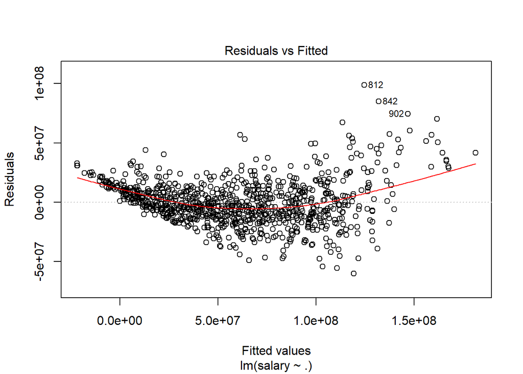

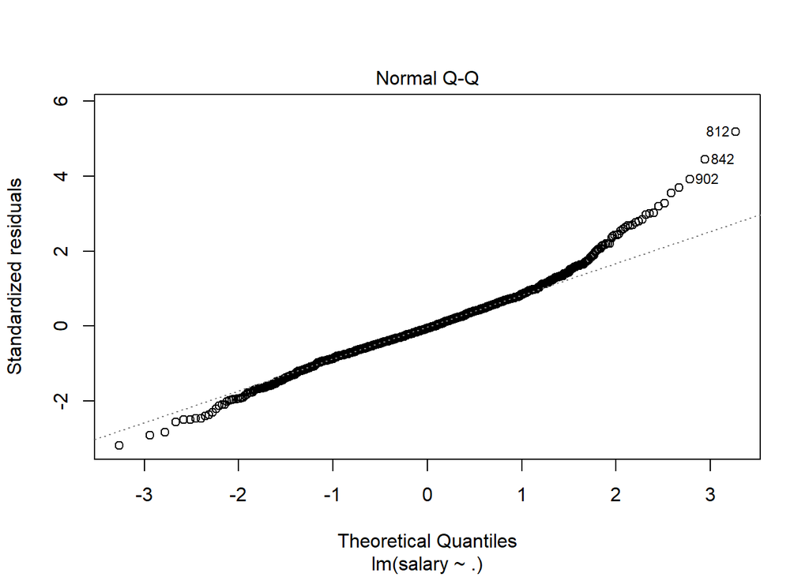

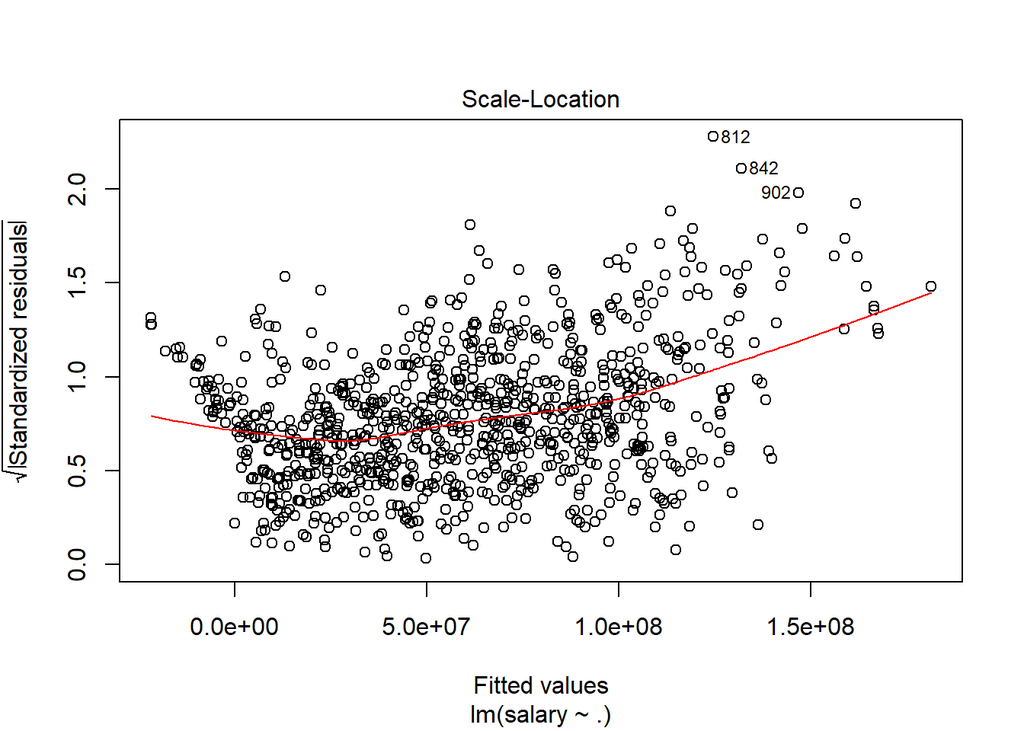

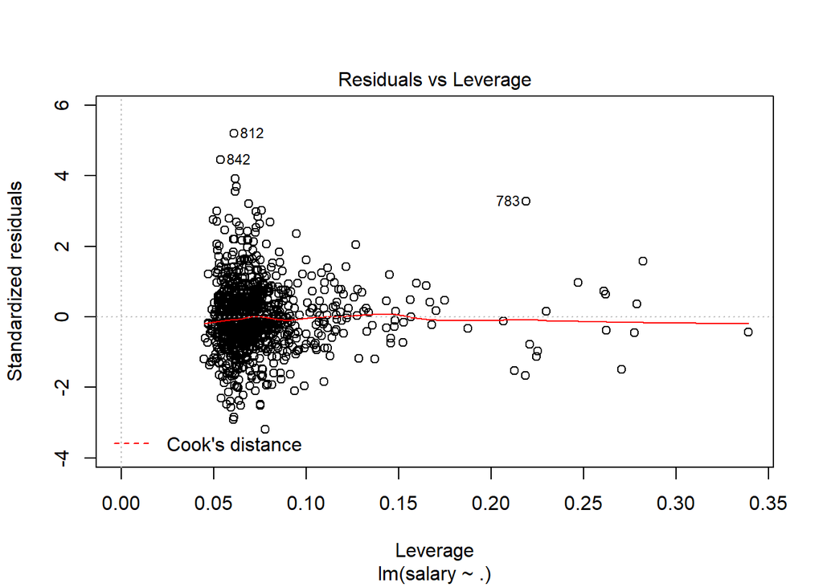

```r
plot(Teammodel)
```

當我們建立出一個線性回歸時，必須要確認其殘差(residual)是否符合下面三個假設：

常態性(Normality)

獨立性(Independence)

變異數同質性(Homogeneity of Variance)

故首先我們要先從回歸模型中找到殘差的值，可以使用names()函式，查看回歸模型內具有的資訊

```r
str(Teammodel)
```

```
## List of 13
##  $ coefficients : Named num [1:71] -8.46e+09 3.90e+06 -5.51e+07 -4.02e+07 8.42e+05 ...
##   ..- attr(*, "names")= chr [1:71] "(Intercept)" "yearID" "teamIDARI" "teamIDATL" ...
##  $ residuals    : Named num [1:918] 16511205 10116678 -16605751 10037183 3878249 ...
##   ..- attr(*, "names")= chr [1:918] "1" "2" "3" "4" ...
##  $ effects      : Named num [1:918] -1.82e+09 1.01e+09 4.69e+07 2.72e+07 7.29e+06 ...
##   ..- attr(*, "names")= chr [1:918] "(Intercept)" "yearID" "teamIDARI" "teamIDATL" ...
##  $ rank         : int 70
##  $ fitted.values: Named num [1:918] -1704205 1444034 27503311 4390711 5967929 ...
##   ..- attr(*, "names")= chr [1:918] "1" "2" "3" "4" ...
##  $ assign       : int [1:71] 0 1 2 2 2 2 2 2 2 2 ...
##  $ qr           :List of 5
##   ..$ qr   : num [1:918, 1:71] -30.299 0.033 0.033 0.033 0.033 ...
##   .. ..- attr(*, "dimnames")=List of 2
##   .. .. ..$ : chr [1:918] "1" "2" "3" "4" ...
##   .. .. ..$ : chr [1:71] "(Intercept)" "yearID" "teamIDARI" "teamIDATL" ...
##   .. ..- attr(*, "assign")= int [1:71] 0 1 2 2 2 2 2 2 2 2 ...
##   .. ..- attr(*, "contrasts")=List of 2
##   .. .. ..$ teamID: chr "contr.treatment"
##   .. .. ..$ lgID  : chr "contr.treatment"
##   ..$ qraux: num [1:71] 1.03 1.06 1 1.01 1.02 ...
##   ..$ pivot: int [1:71] 1 2 3 4 5 6 7 8 9 10 ...
##   ..$ tol  : num 1e-07
##   ..$ rank : int 70
##   ..- attr(*, "class")= chr "qr"
##  $ df.residual  : int 848
##  $ contrasts    :List of 2
##   ..$ teamID: chr "contr.treatment"
##   ..$ lgID  : chr "contr.treatment"
##  $ xlevels      :List of 2
##   ..$ teamID: chr [1:35] "ANA" "ARI" "ATL" "BAL" ...
##   ..$ lgID  : chr [1:2] "AL" "NL"
##  $ call         : language lm(formula = salary ~ ., data = Teams1985_2016)
##  $ terms        :Classes 'terms', 'formula'  language salary ~ yearID + teamID + lgID + G + Ghome + W + L + R + AB + H + X2B +      X3B + HR + BB + SO + SB + CS + HBP | __truncated__ ...
##   .. ..- attr(*, "variables")= language list(salary, yearID, teamID, lgID, G, Ghome, W, L, R, AB, H, X2B, X3B,      HR, BB, SO, SB, CS, HBP, SF, RA, ER, | __truncated__ ...
##   .. ..- attr(*, "factors")= int [1:38, 1:37] 0 1 0 0 0 0 0 0 0 0 ...
##   .. .. ..- attr(*, "dimnames")=List of 2
##   .. .. .. ..$ : chr [1:38] "salary" "yearID" "teamID" "lgID" ...
##   .. .. .. ..$ : chr [1:37] "yearID" "teamID" "lgID" "G" ...
##   .. ..- attr(*, "term.labels")= chr [1:37] "yearID" "teamID" "lgID" "G" ...
```

[output cut: 46 more lines]

```
##   ..- attr(*, "terms")=Classes 'terms', 'formula'  language salary ~ yearID + teamID + lgID + G + Ghome + W + L + R + AB + H + X2B +      X3B + HR + BB + SO + SB + CS + HBP | __truncated__ ...
##   .. .. ..- attr(*, "variables")= language list(salary, yearID, teamID, lgID, G, Ghome, W, L, R, AB, H, X2B, X3B,      HR, BB, SO, SB, CS, HBP, SF, RA, ER, | __truncated__ ...
##   .. .. ..- attr(*, "factors")= int [1:38, 1:37] 0 1 0 0 0 0 0 0 0 0 ...
##   .. .. .. ..- attr(*, "dimnames")=List of 2
##   .. .. .. .. ..$ : chr [1:38] "salary" "yearID" "teamID" "lgID" ...
##   .. .. .. .. ..$ : chr [1:37] "yearID" "teamID" "lgID" "G" ...
##   .. .. ..- attr(*, "term.labels")= chr [1:37] "yearID" "teamID" "lgID" "G" ...
##   .. .. ..- attr(*, "order")= int [1:37] 1 1 1 1 1 1 1 1 1 1 ...
##   .. .. ..- attr(*, "intercept")= int 1
##   .. .. ..- attr(*, "response")= int 1
##   .. .. ..- attr(*, ".Environment")=<environment: R_GlobalEnv>
##   .. .. ..- attr(*, "predvars")= language list(salary, yearID, teamID, lgID, G, Ghome, W, L, R, AB, H, X2B, X3B,      HR, BB, SO, SB, CS, HBP, SF, RA, ER, | __truncated__ ...
##   .. .. ..- attr(*, "dataClasses")= Named chr [1:38] "numeric" "numeric" "factor" "factor" ...
##   .. .. .. ..- attr(*, "names")= chr [1:38] "salary" "yearID" "teamID" "lgID" ...
##  - attr(*, "class")= chr "lm"
```

```r
names(Teammodel)
```

```
##  [1] "coefficients"  "residuals"     "effects"       "rank"
##  [5] "fitted.values" "assign"        "qr"            "df.residual"
##  [9] "contrasts"     "xlevels"       "call"          "terms"
## [13] "model"
```

其中，residuals就是指殘差的值(coefficients代表係數)，因此我們可以取出來後進行上面三個假設的檢定： 常態性假設 shapiro.test()函式可以用來檢驗殘差的常態性：

```r
shapiro.test(Teammodel$residual)
```

```
##
##  Shapiro-Wilk normality test
##
## data:  Teammodel$residual
## W = 0.97298, p-value = 5.033e-12
```

虛無假設H0:殘差服從常態分配，因為p-value < 0.05，代表拒絕H0。

獨立性假設 要檢驗殘差的獨立性，需要使用套件car中的durbinWatsonTest()函式：

```r
# 因為這個函式會自動去抓模型中的殘差，故這裡放的是模型，而不是殘差的值
durbinWatsonTest(Teammodel)
```

```
##  lag Autocorrelation D-W Statistic p-value
##    1      0.01119571      1.976132   0.624
##  Alternative hypothesis: rho != 0
```

虛無假設H0:殘差間相互獨立，因為p-value > 0.05，代表不拒絕H0。

變異數同質性假設 要檢驗殘差的變異數同質性，需要使用套件car中的ncvTest()函式：

```r
# 因為這個函式會自動去抓模型中的殘差，故這裡放的是模型，而不是殘差的值
ncvTest(Teammodel)
```

```
## Non-constant Variance Score Test
## Variance formula: ~ fitted.values
## Chisquare = 228.007, Df = 1, p = < 2.22e-16
```

虛無假設H0:殘差變異數具有同質性，因為p-value < 0.05，代表拒絕H0。

#### pcr

```
## Data:    X dimension: 918 34
##  Y dimension: 918 1
## Fit method: svdpc
## Number of components considered: 34
##
## VALIDATION: RMSEP
## Cross-validated using 10 random segments.
##        (Intercept)   1 comps   2 comps   3 comps   4 comps   5 comps   6 comps
## CV        43333532  42910106  39943719  32777651  30025974  29723687  29781227
## adjCV     43333532  42895432  39938733  32760926  30015821  29710652  29775362
##         7 comps   8 comps   9 comps  10 comps  11 comps  12 comps  13 comps
## CV     29699378  29639966  29642833  29377760  29404981  29499602  29508638
## adjCV  29682972  29622329  29624632  29331142  29374942  29472376  29482060
##        14 comps  15 comps  16 comps  17 comps  18 comps  19 comps  20 comps
## CV     29542633  29110094  29136356  29115017  28672131  28634099  28046354
## adjCV  29528856  29075383  29103755  29113342  28613066  28594289  28005290
##        21 comps  22 comps  23 comps  24 comps  25 comps  26 comps  27 comps
## CV     27961080  27970749  27780551  27808056  27836560  27750208  27738968
## adjCV  27919942  27928055  27733489  27762654  27789319  27701613  27708726
##        28 comps  29 comps  30 comps  31 comps  32 comps  33 comps  34 comps
## CV     27599447  27604399  27616860  27624579  27637260  27645745  27671980
## adjCV  27547736  27551596  27561513  27569529  27581387  27589020  27607504
##
## TRAINING: % variance explained
##         1 comps  2 comps  3 comps  4 comps  5 comps  6 comps  7 comps  8 comps
## X        24.794    45.41    57.04    66.39    72.05    75.65    79.14    81.92
## salary    2.244    15.50    43.20    52.53    53.59    53.59    53.85    54.19
##         9 comps  10 comps  11 comps  12 comps  13 comps  14 comps  15 comps
## X         84.36     86.49      88.5     90.42     92.02     93.41     94.70
## salary    54.29     55.20      55.2     55.23     55.23     55.35     56.67
##         16 comps  17 comps  18 comps  19 comps  20 comps  21 comps  22 comps
## X          95.85     96.67     97.44     98.17     98.76     99.18     99.50
## salary     56.72     56.88     58.38     58.58     60.27     60.59     60.64
##         23 comps  24 comps  25 comps  26 comps  27 comps  28 comps  29 comps
## X          99.66     99.79     99.88     99.91     99.94     99.96     99.98
## salary     61.18     61.24     61.29     61.61     61.64     62.16     62.23
##         30 comps  31 comps  32 comps  33 comps  34 comps
## X          99.99    100.00     100.0    100.00    100.00
## salary     62.29     62.29      62.3     62.32     62.32
```

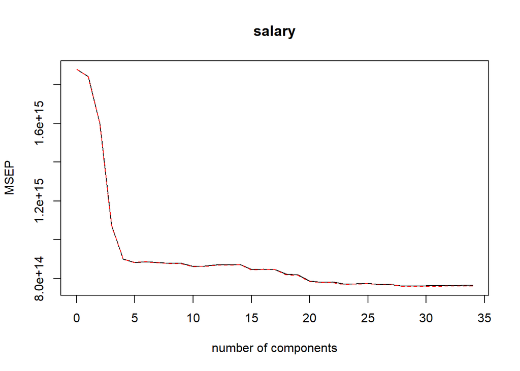

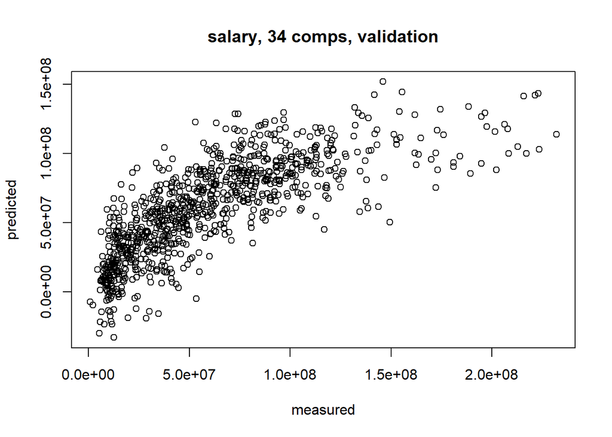

```
## , , 5 comps
##
##                    salary
## (Intercept) -1782728469.4
## G                751260.1
## Ghome            768809.4
## W                923419.7
## L               -355674.5
## R               -339063.1
## AB               783015.3
## H               -159361.0
## X2B             2388298.2
## X3B            -1661079.6
## HR              2300284.9
## BB             -1541169.7
## SO              5028621.5
## SB             -3682457.6
## CS             -5008565.9
## HBP             3907723.1
## SF             -2558903.3
## RA             -1012925.5
## ER              -355934.1
## ERA             -701093.8
## CG             -5192275.9
## SHO             1457279.2
## SV              1440707.9
## IPouts           761357.4
## HA              -581331.0
## HRA             1736944.6
## BBA            -1874553.0
## SOA             5424882.1
## E              -5374160.3
## DP              -632162.5
## FP              5538279.5
## BPF             1059275.1
## PPF              941951.4
## RD               647068.2
## Wpct             678207.1
```

```
## , , 1 comps
##
##                    salary
## (Intercept) -54693524.007
## G              561209.818
## Ghome          552364.682
## W               36484.445
## L              376139.181
## R              470819.457
## AB             616625.174
## H              583047.567
## X2B            477736.417
## X3B             60664.616
## HR             378958.970
## BB             272077.452
## SO             299024.195
## SB             -61563.283
## CS             -62425.717
## HBP            289826.730
## SF             179240.545
## RA             636332.031
## ER             644077.182
## ERA            417361.739
## CG            -173656.067
## SHO           -224512.855
## SV               -211.103
## IPouts         519684.851
## HA             684192.089
## HRA            537462.595
## BBA            438207.232
## SOA            173489.204
## E              124491.175
## DP             411822.815
## FP              35879.363
## BPF            146474.229
## PPF            173354.792
## RD            -177226.795
## Wpct          -182992.020
##
## , , 2 comps
```

[output cut: 139 more lines]

```
## CG             -5192275.9
## SHO             1457279.2
## SV              1440707.9
## IPouts           761357.4
## HA              -581331.0
## HRA             1736944.6
## BBA            -1874553.0
## SOA             5424882.1
## E              -5374160.3
## DP              -632162.5
## FP              5538279.5
## BPF             1059275.1
## PPF              941951.4
## RD               647068.2
## Wpct             678207.1
```

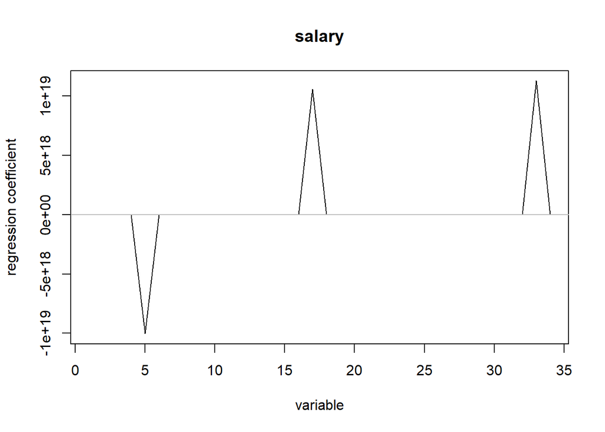

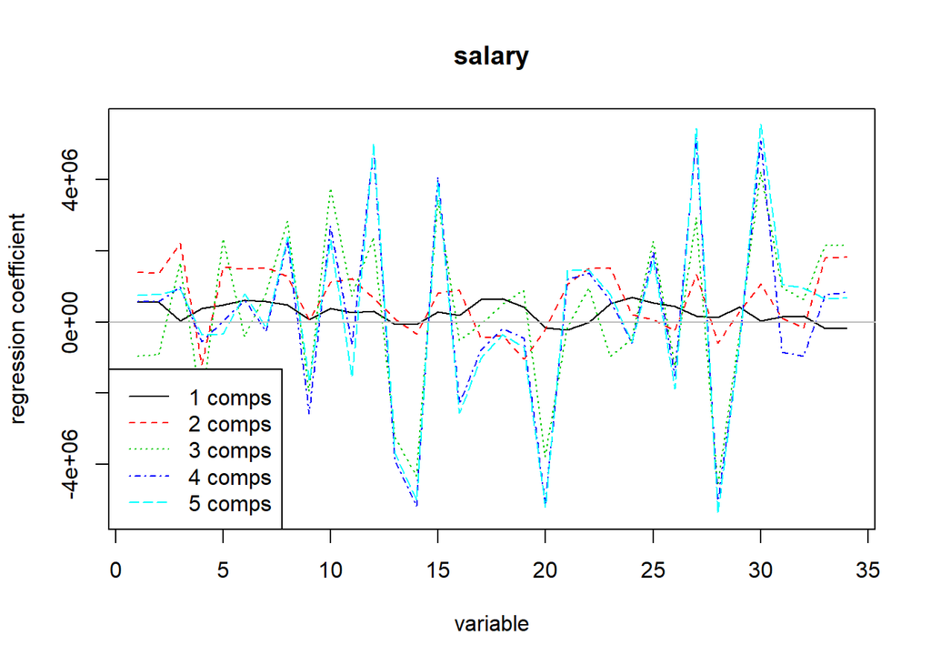

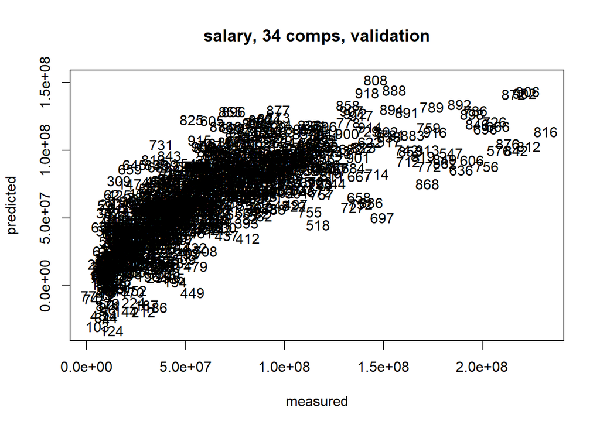

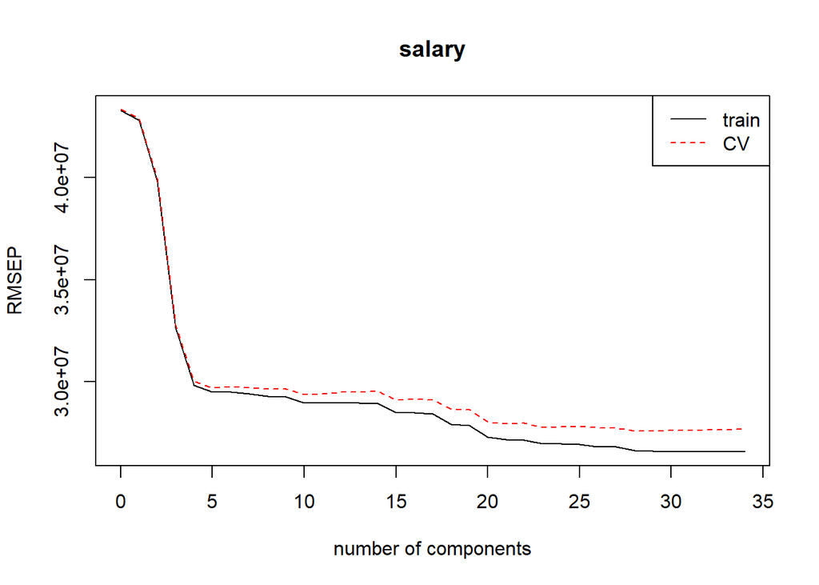

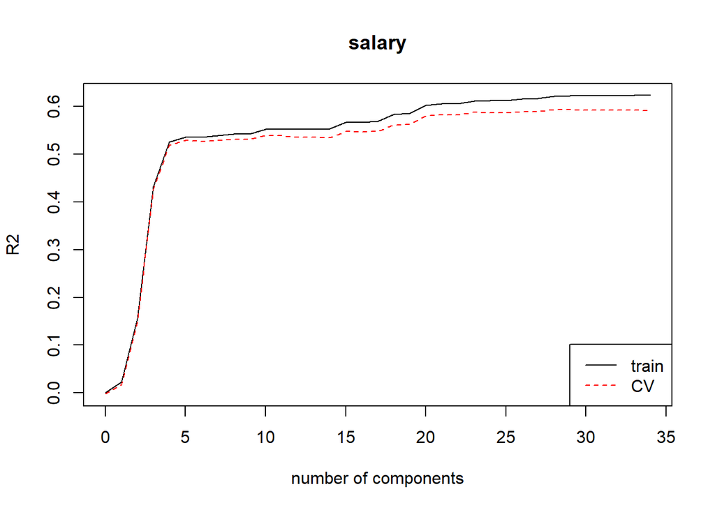

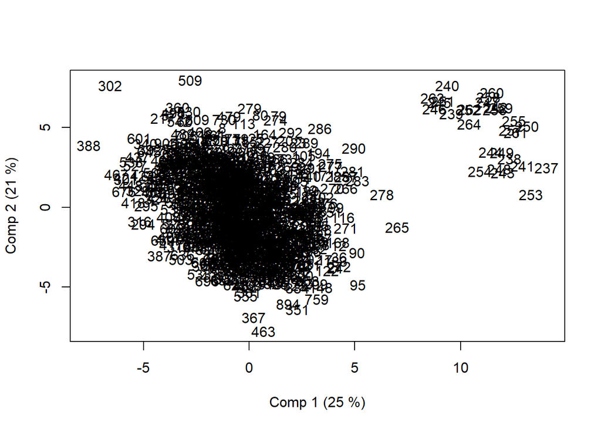